# Module 200

#### Hemi-module gene counts:

458 probesets in hemi-module A.  
78 probesets in hemi-module B.  
Note: While the mapping of probesets to genes is usually one-to-one, some genes are targeted by multiple probesets, some probesets target multiple genes, and some probesets do not target any genes (i.e., the region of the genome they match is no longer considered genic).

#### Contrast SVE:

Signed variance explained (SVE) provides an indication of how similar a set of fold changes are to a gene module’s weight vector. An SVE value of 0.3, for example, indicates that 30% of the variance explained by the entire module set is accounted for by the module in question. Shown here are the SVE values for this module across a compendium of fold changes (contrasts). Extreme SVE values (e.g., > 0.05) indicate that those contrasts specifically induce (orange dots) or specifically repress (blue dots) this module. Examining the experimental conditions being compared in such contrasts (see tables below the figure) may provide insight into the gene module’s function.

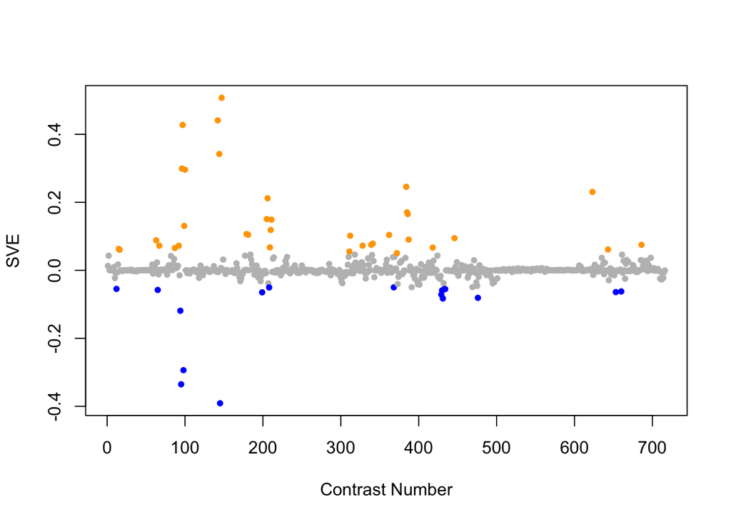

Positive SVE Contrasts:

|  | Contrast.Num | SVE | GEO.GSE | Cond.1 | Cond.2 | Mutation |
| --- | --- | --- | --- | --- | --- | --- |
| GSE50513.s4t1.vs.s3t1 | 147 | 0.51 | GSE50513 | zip-2 PA14 - rep 1 | zip-2 OP50 - rep 1 |  |
| GSE50513.s2t1.vs.s1t1 | 142 | 0.44 | GSE50513 | L4440 PA14 - rep 1 | L4440 OP50 - rep 1 |  |
| GSE5793.s3t1.vs.s2t1 | 97 | 0.43 | GSE5793 | Celegans_PA14_4hours_RepA | Celegans_OP50_4hours_RepA |  |
| GSE50513.s4t1.vs.s1t1 | 144 | 0.34 | GSE50513 | zip-2 PA14 - rep 1 | L4440 OP50 - rep 1 |  |
| GSE5793.s3t1.vs.s1t1 | 96 | 0.30 | GSE5793 | Celegans_PA14_4hours_RepA | Celegans_gacA_4hours_RepA |  |
| GSE5793.s3t2.vs.s2t2 | 100 | 0.30 | GSE5793 | Celegans_PA14_8hours_RepA | Celegans_OP50_8hours_RepA |  |
| GSE34026.s4t1.vs.s0t1 | 384 | 0.25 | GSE34026 | N2 exposed to CVD109, biological rep1 | N2 exposed to OP50(E.coli), biological rep1 |  |
| GSE20053.s1t1.vs.s0t1 | 623 | 0.23 | GSE20053 | C. elegans N2_Y. pestis KIM5_24h_Sample A | C. elegans N2_E. coli OP50_24h_Sample A |  |
| GSE42703.s2t2.vs.s1t2 | 206 | 0.21 | GSE42703 | WT incubated with H2O, biological rep1 | kgb-1 incubated with H2O, biological rep1 | kgb-1 |
| GSE34026.s3t1.vs.s0t1 | 385 | 0.17 | GSE34026 | N2 exposed to CVD110, biological rep1 | N2 exposed to OP50(E.coli), biological rep1 |  |
| GSE34026.s2t1.vs.s0t1 | 386 | 0.17 | GSE34026 | N2 exposed to E7946, biological rep1 | N2 exposed to OP50(E.coli), biological rep1 |  |
| GSE42703.s2t1.vs.s1t1 | 205 | 0.15 | GSE42703 | WT incubated with 1mM copper sulfate, biological rep1 | kgb-1 incubated with 1mM copper sulfate, biological rep1 | kgb-1 |
| GSE42689.s4t1.vs.s1t1 | 211 | 0.15 | GSE42689 | mlk-1 fed 1 | mek-1 fasted 1 |  |
| GSE5793.s3t2.vs.s1t2 | 99 | 0.13 | GSE5793 | Celegans_PA14_8hours_RepA | Celegans_gacA_8hours_RepA |  |
| GSE42689.s3t1.vs.s1t1 | 210 | 0.12 | GSE42689 | mlk-1 fasted 1 | mek-1 fasted 1 |  |
| GSE47778.s2t3.vs.s2t1 | 179 | 0.11 | GSE47778 | daf-2; UV; replicate 1 | daf-2; replicate 1 |  |
| GSE47778.s4t3.vs.s4t1 | 181 | 0.10 | GSE47778 | daf-2;daf-16; UV; replicate 1 | daf-2;daf-16; replicate 1 |  |
| GSE37266.s1t1.vs.s0t1 | 362 | 0.10 | GSE37266 | RPW-24 G | DMSO G |  |
| GSE41056.s1t2.vs.s1t1 | 312 | 0.10 | GSE41056 | JU1580_inf_1 | JU1580_1 |  |
| GSE27401.s2t1.vs.s3t1 | 446 | 0.09 | GSE27401 | Heat Killed C. albicans #1 | C. albicans alive #1 |  |
| GSE34026.s1t1.vs.s0t1 | 387 | 0.09 | GSE34026 | N2 exposed to hemolysin mutant of E7946, biological rep1 | N2 exposed to OP50(E.coli), biological rep1 |  |
| GSE8696.s3t1.vs.s2t1 | 63 | 0.09 | GSE8696 | 500 uM hemin (500A) | 20 uM hemin (20A) |  |
| GSE38997.s3t1.vs.s2t1 | 341 | 0.08 | GSE38997 | experiment 4 UVC- and EtBr-exposed samples at 3 h 4eu3 | experiment 4 EtBr-exposed samples at 3 h 4e3 |  |
| GSE38997.s3t1.vs.s1t1 | 339 | 0.08 | GSE38997 | experiment 4 UVC- and EtBr-exposed samples at 3 h 4eu3 | experiment 4 control samples at 3 h 4c3 |  |
| GSE12298C.s1t1.vs.s0t1 | 686 | 0.07 | GSE12298 | mefloquine_low_dose-rep1 | mefloquine_control-rep1 |  |
| GSE38997.s4t4.vs.s1t4 | 328 | 0.07 | GSE38997 | experiment 1 UVC-exposed samples at 51 h 1u51 | experiment 1 control samples at 51 h 1c51 |  |
| GSE8659.s3t1.vs.s2t1 | 67 | 0.07 | GSE8659 | strain NL 2099 replicate 2 | strain GR1373 replicate 1 |  |
| GSE5801.s2t1.vs.s1t1 | 92 | 0.07 | GSE5801 | daf2daf16_RepA | daf2_RepA | daf-16 |
| GSE42689.s2t1.vs.s1t1 | 209 | 0.07 | GSE42689 | mek-1 fed 1 | mek-1 fasted 1 |  |
| GSE28856.s0t3.vs.s0t1 | 418 | 0.07 | GSE28856 | Wild-type 2 h after shifting temperature rep1 | Wild-type 0 h after shifting temperature rep1 |  |
| GSE6547.s1t3.vs.s0t3 | 87 | 0.07 | GSE6547 | lin-35(n745) worms at L4 stage, first replicate | N2 (wt) worms at L4 stage, first replicate | lin-35 |
| GSE9682.s2t2.vs.s2t1 | 15 | 0.06 | GSE9682 | N2-Cel-TORRNAi-fed-biological rep1 | N2-Cel-TORRNAi-fasting-biological rep1 |  |
| GSE16975.s1t1.vs.s0t1 | 643 | 0.06 | GSE16975 | C.elegans hydrogen sulfide sample replicate 1 | C.elegans control sample replicate 1 |  |
| GSE9682.s0t2.vs.s0t1 | 16 | 0.06 | GSE9682 | N2-controlRNAi-fed-biological rep1 | N2-controlRNAi-fasting-biological rep1 |  |
| GSE41056.s2t2.vs.s0t2 | 311 | 0.06 | GSE41056 | RDE_1_inf_1 | N2_inf_1 | rde-1 |
| GSE35360C.s2t1.vs.s0t1 | 372 | 0.05 | GSE35360 | HFHQ 3d_2.0_rep1 | HFHQ 3d control_rep1 |  |

Negative SVE Contrasts:

|  | Contrast.Num | SVE | GEO.GSE | Cond.1 | Cond.2 | Mutation |
| --- | --- | --- | --- | --- | --- | --- |
| GSE50513.s3t1.vs.s2t1 | 145 | -0.39 | GSE50513 | zip-2 OP50 - rep 1 | L4440 PA14 - rep 1 |  |
| GSE5793.s2t1.vs.s1t1 | 95 | -0.34 | GSE5793 | Celegans_OP50_4hours_RepA | Celegans_gacA_4hours_RepA |  |
| GSE5793.s2t2.vs.s1t2 | 98 | -0.29 | GSE5793 | Celegans_OP50_8hours_RepA | Celegans_gacA_8hours_RepA |  |
| GSE5801.s3t1.vs.s2t1 | 94 | -0.12 | GSE5801 | daf2pmk1_RepA | daf2daf16_RepA |  |
| GSE27677A.s3t2.vs.s3t1 | 431 | -0.08 | GSE27677 | daf-16, Fast , rep 1 | daf-16, Fed , rep 1 |  |
| GSE23528A.s1t6.vs.s1t1 | 476 | -0.08 | GSE23528 | Adult at T22 in LD, time-series experiment 3 | Adult at T2 in LD, time-series experiment 3 |  |
| GSE27677A.s2t1.vs.s0t1 | 429 | -0.07 | GSE27677 | jun-1, Fed , rep 1 | N2, Fed , rep 1 | 40694 |
| GSE43959.s1t2.vs.s4t2 | 199 | -0.06 | GSE43959 | N2 gravid adult on E. coli OP50 rep 1 | N2 gravid adult on 1:1000 Comamonas DA1877 rep 1 |  |
| GSE16405.s4t1.vs.s2t1 | 653 | -0.06 | GSE16405 | xpa-1_1 | nth-1_1 | nth-1 vs. xpa-1 |
| GSE15527.s2t1.vs.s1t1 | 660 | -0.06 | GSE15527 | sma-6 L4 worm, biological rep1 | dbl-1 L4 worm, biological rep1 | dbl-1 |
| GSE27677A.s1t1.vs.s0t1 | 430 | -0.06 | GSE27677 | kgb-1, Fed , rep 1 | N2, Fed , rep 1 | kgb-1 |
| GSE8659.s2t1.vs.s1t1 | 65 | -0.06 | GSE8659 | strain GR1373 replicate 1 | N2 replicate 1 | eri-1 |
| GSE27677A.s0t2.vs.s0t1 | 434 | -0.06 | GSE27677 | N2, Fast , rep 1 | N2, Fed , rep 1 |  |
| GSE27677A.s1t2.vs.s1t1 | 433 | -0.05 | GSE27677 | kgb-1, Fast , rep 1 | kgb-1, Fed , rep 1 |  |
| GSE9682.s1t2.vs.s0t2 | 12 | -0.05 | GSE9682 | N2-Cel-RhebRNAi-fed-biological rep1 | N2-controlRNAi-fed-biological rep1 | Rheb |
| GSE42703.s2t2.vs.s2t1 | 208 | -0.05 | GSE42703 | WT incubated with H2O, biological rep1 | WT incubated with 1mM copper sulfate, biological rep1 |  |
| GSE35360A.s2t1.vs.s0t1 | 368 | -0.05 | GSE35360 | HF 11d_2.0_rep1 | HF 11d control_rep1 |  |

$~$

#### Contrast SVE, Up-Regulated Genes Only:

Calculating SVE for up-regulated and down-regulated genes separately may be more informative in many cases than projecting the up- and down- gene sets together. This is due to the fact that the weight distribution of many modules is highly skewed, indicating that only one of the hemi-modules may be biologically meaningful (i.e., a set of genes are strongly correlated by only a few genes (or none) are strongly anti-correlated to that set.)

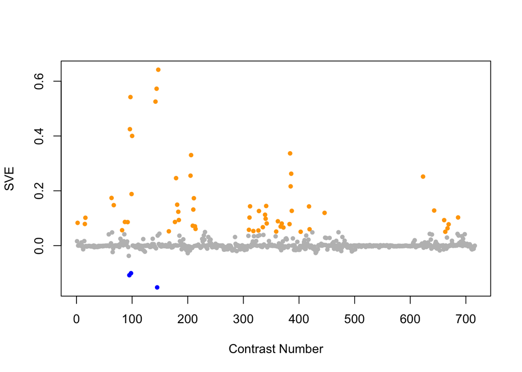

Positive SVE Contrasts:

|  | Contrast.Num | SVE | GEO.GSE | Cond.1 | Cond.2 | Mutation |
| --- | --- | --- | --- | --- | --- | --- |
| GSE50513.s4t1.vs.s3t1 | 147 | 0.64 | GSE50513 | zip-2 PA14 - rep 1 | zip-2 OP50 - rep 1 |  |
| GSE50513.s4t1.vs.s1t1 | 144 | 0.57 | GSE50513 | zip-2 PA14 - rep 1 | L4440 OP50 - rep 1 |  |
| GSE5793.s3t1.vs.s2t1 | 97 | 0.54 | GSE5793 | Celegans_PA14_4hours_RepA | Celegans_OP50_4hours_RepA |  |
| GSE50513.s2t1.vs.s1t1 | 142 | 0.53 | GSE50513 | L4440 PA14 - rep 1 | L4440 OP50 - rep 1 |  |
| GSE5793.s3t1.vs.s1t1 | 96 | 0.42 | GSE5793 | Celegans_PA14_4hours_RepA | Celegans_gacA_4hours_RepA |  |
| GSE5793.s3t2.vs.s2t2 | 100 | 0.40 | GSE5793 | Celegans_PA14_8hours_RepA | Celegans_OP50_8hours_RepA |  |
| GSE34026.s4t1.vs.s0t1 | 384 | 0.34 | GSE34026 | N2 exposed to CVD109, biological rep1 | N2 exposed to OP50(E.coli), biological rep1 |  |
| GSE42703.s2t2.vs.s1t2 | 206 | 0.33 | GSE42703 | WT incubated with H2O, biological rep1 | kgb-1 incubated with H2O, biological rep1 | kgb-1 |
| GSE34026.s2t1.vs.s0t1 | 386 | 0.26 | GSE34026 | N2 exposed to E7946, biological rep1 | N2 exposed to OP50(E.coli), biological rep1 |  |
| GSE42703.s2t1.vs.s1t1 | 205 | 0.26 | GSE42703 | WT incubated with 1mM copper sulfate, biological rep1 | kgb-1 incubated with 1mM copper sulfate, biological rep1 | kgb-1 |
| GSE20053.s1t1.vs.s0t1 | 623 | 0.25 | GSE20053 | C. elegans N2_Y. pestis KIM5_24h_Sample A | C. elegans N2_E. coli OP50_24h_Sample A |  |
| GSE47778.s2t3.vs.s2t1 | 179 | 0.25 | GSE47778 | daf-2; UV; replicate 1 | daf-2; replicate 1 |  |
| GSE34026.s3t1.vs.s0t1 | 385 | 0.22 | GSE34026 | N2 exposed to CVD110, biological rep1 | N2 exposed to OP50(E.coli), biological rep1 |  |
| GSE5793.s3t2.vs.s1t2 | 99 | 0.19 | GSE5793 | Celegans_PA14_8hours_RepA | Celegans_gacA_8hours_RepA |  |
| GSE8696.s3t1.vs.s2t1 | 63 | 0.17 | GSE8696 | 500 uM hemin (500A) | 20 uM hemin (20A) |  |
| GSE42689.s4t1.vs.s1t1 | 211 | 0.17 | GSE42689 | mlk-1 fed 1 | mek-1 fasted 1 |  |
| GSE47778.s4t3.vs.s4t1 | 181 | 0.15 | GSE47778 | daf-2;daf-16; UV; replicate 1 | daf-2;daf-16; replicate 1 |  |
| GSE8659.s3t1.vs.s2t1 | 67 | 0.15 | GSE8659 | strain NL 2099 replicate 2 | strain GR1373 replicate 1 |  |
| GSE38997.s3t1.vs.s2t1 | 341 | 0.14 | GSE38997 | experiment 4 UVC- and EtBr-exposed samples at 3 h 4eu3 | experiment 4 EtBr-exposed samples at 3 h 4e3 |  |
| GSE41056.s1t2.vs.s1t1 | 312 | 0.14 | GSE41056 | JU1580_inf_1 | JU1580_1 |  |
| GSE28856.s0t3.vs.s0t1 | 418 | 0.14 | GSE28856 | Wild-type 2 h after shifting temperature rep1 | Wild-type 0 h after shifting temperature rep1 |  |
| GSE42689.s3t1.vs.s1t1 | 210 | 0.13 | GSE42689 | mlk-1 fasted 1 | mek-1 fasted 1 |  |
| GSE16975.s1t1.vs.s0t1 | 643 | 0.13 | GSE16975 | C.elegans hydrogen sulfide sample replicate 1 | C.elegans control sample replicate 1 |  |
| GSE34026.s1t1.vs.s0t1 | 387 | 0.13 | GSE34026 | N2 exposed to hemolysin mutant of E7946, biological rep1 | N2 exposed to OP50(E.coli), biological rep1 |  |
| GSE38997.s4t4.vs.s1t4 | 328 | 0.13 | GSE38997 | experiment 1 UVC-exposed samples at 51 h 1u51 | experiment 1 control samples at 51 h 1c51 |  |
| GSE47778.s1t3.vs.s1t1 | 183 | 0.12 | GSE47778 | N2; UV; replicate 1 | N2; replicate 1 |  |
| GSE27401.s2t1.vs.s3t1 | 446 | 0.12 | GSE27401 | Heat Killed C. albicans #1 | C. albicans alive #1 |  |
| GSE38997.s3t1.vs.s1t1 | 339 | 0.11 | GSE38997 | experiment 4 UVC- and EtBr-exposed samples at 3 h 4eu3 | experiment 4 control samples at 3 h 4c3 |  |
| GSE12298C.s1t1.vs.s0t1 | 686 | 0.10 | GSE12298 | mefloquine_low_dose-rep1 | mefloquine_control-rep1 |  |
| GSE41056.s2t2.vs.s0t2 | 311 | 0.10 | GSE41056 | RDE_1_inf_1 | N2_inf_1 | rde-1 |
| GSE9682.s0t2.vs.s0t1 | 16 | 0.10 | GSE9682 | N2-controlRNAi-fed-biological rep1 | N2-controlRNAi-fasting-biological rep1 |  |
| GSE38997.s4t1.vs.s1t1 | 340 | 0.10 | GSE38997 | experiment 4 UVC-exposed samples at 3 h 4u3 | experiment 4 control samples at 3 h 4c3 |  |
| GSE47778.s5t3.vs.s5t1 | 184 | 0.09 | GSE47778 | xpa-1 10mJ/cm2; replicate 1 | xpa-1 0mJ/cm2; replicate 1 |  |
| GSE15159.s1t1.vs.s0t1 | 661 | 0.09 | GSE15159 | glp-1_control_2007_rep1 | N2_control_2007_rep1 | glp-1 |
| GSE37266.s1t1.vs.s0t1 | 362 | 0.09 | GSE37266 | RPW-24 G | DMSO G |  |
| GSE6547.s1t3.vs.s0t3 | 87 | 0.09 | GSE6547 | lin-35(n745) worms at L4 stage, first replicate | N2 (wt) worms at L4 stage, first replicate | lin-35 |
| GSE47778.s3t3.vs.s3t1 | 177 | 0.09 | GSE47778 | daf-16; UV; replicate 1 | daf-16; replicate 1 |  |
| GSE5801.s2t1.vs.s1t1 | 92 | 0.09 | GSE5801 | daf2daf16_RepA | daf2_RepA | daf-16 |
| GSE9897A.s2t1.vs.s0t1 | 2 | 0.08 | GSE9897 | Complex II missense mutant | Wildtype (control for missense) | mev-1 |
| GSE38997.s4t1.vs.s2t1 | 342 | 0.08 | GSE38997 | experiment 4 UVC-exposed samples at 3 h 4u3 | experiment 4 EtBr-exposed samples at 3 h 4e3 |  |
| GSE35360B.s1t1.vs.s0t1 | 369 | 0.08 | GSE35360 | HF 3d_0.2_rep1 | HF 3d control_rep1 |  |
| GSE9682.s2t2.vs.s2t1 | 15 | 0.08 | GSE9682 | N2-Cel-TORRNAi-fed-biological rep1 | N2-Cel-TORRNAi-fasting-biological rep1 |  |
| GSE34113.s1t1.vs.s0t1 | 383 | 0.08 | GSE34113 | tdp-1(ok803) | wild-type 1 | tdp-1 |
| GSE15016.s3t1.vs.s0t1 | 669 | 0.08 | GSE15016 | young adult_24hr DEHP exposure_rep1 | young adult_not exposured_rep1 |  |
| GSE42689.s2t1.vs.s1t1 | 209 | 0.07 | GSE42689 | mek-1 fed 1 | mek-1 fasted 1 |  |
| GSE42689.s4t1.vs.s2t1 | 213 | 0.07 | GSE42689 | mlk-1 fed 1 | mek-1 fed 1 |  |
| GSE35360A.s1t1.vs.s0t1 | 367 | 0.07 | GSE35360 | HF 11d_0.2_rep1 | HF 11d control_rep1 |  |
| GSE38997.s3t2.vs.s2t2 | 335 | 0.07 | GSE38997 | experiment 4 UVC- and EtBr-exposed samples at 24 h 4eu24 | experiment 4 EtBr-exposed samples at 24 h 4e24 |  |
| GSE35360C.s2t1.vs.s0t1 | 372 | 0.07 | GSE35360 | HFHQ 3d_2.0_rep1 | HFHQ 3d control_rep1 |  |
| GSE15159.s2t2.vs.s2t1 | 667 | 0.06 | GSE15159 | xpa-1_UV_2007_rep1 | xpa-1_control_2007_rep1 |  |
| GSE42689.s4t1.vs.s3t1 | 214 | 0.06 | GSE42689 | mlk-1 fed 1 | mlk-1 fasted 1 |  |
| GSE28856.s0t4.vs.s0t1 | 419 | 0.06 | GSE28856 | Wild-type 4 h after shifting temperature rep1 | Wild-type 0 h after shifting temperature rep1 |  |
| GSE41056.s1t2.vs.s0t2 | 310 | 0.06 | GSE41056 | JU1580_inf_1 | N2_inf_1 |  |
| GSE7354.s2t1.vs.s1t1 | 82 | 0.06 | GSE7354 | whole animal, nucleus accumbens: Extract1_le1 | whole animal, nucleus accumbens: Extract-Control_le1 |  |
| GSE38997.s3t4.vs.s1t4 | 327 | 0.06 | GSE38997 | experiment 1 UVC- and EtBr-exposed samples at 51 h 1eu51 | experiment 1 control samples at 51 h 1c51 |  |
| GSE39012.s2t1.vs.s0t1 | 318 | 0.05 | GSE39012 | L3 stage worm AS_.003, biological replicate 1 | L3 stage worm AS_Control, biological replicate 1 |  |
| GSE47778.s2t3.vs.s3t3 | 166 | 0.05 | GSE47778 | daf-2; UV; replicate 1 | daf-16; UV; replicate 1 | daf-2 vs. daf-16 |
| GSE38196.s0t2.vs.s0t1 | 359 | 0.05 | GSE38196 | wild-type-treated, biological rep1 | wild-type-control, biological rep1 | spg-7(RNAi) |
| GSE15159.s1t2.vs.s0t2 | 663 | 0.05 | GSE15159 | glp-1_UV_2007_rep1 | N2_UV_2007_rep1 | glp-1 |
| GSE30505.s3t1.vs.s4t1 | 403 | 0.05 | GSE30505 | L3 glp-1 E.V. #1 | L3 glp-1 ash-2 #1 | ash-2 |

Negative SVE Contrasts:

|  | Contrast.Num | SVE | GEO.GSE | Cond.1 | Cond.2 | Mutation |
| --- | --- | --- | --- | --- | --- | --- |
| GSE50513.s3t1.vs.s2t1 | 145 | -0.15 | GSE50513 | zip-2 OP50 - rep 1 | L4440 PA14 - rep 1 |  |
| GSE5793.s2t1.vs.s1t1 | 95 | -0.11 | GSE5793 | Celegans_OP50_4hours_RepA | Celegans_gacA_4hours_RepA |  |
| GSE5793.s2t2.vs.s1t2 | 98 | -0.10 | GSE5793 | Celegans_OP50_8hours_RepA | Celegans_gacA_8hours_RepA |  |
| GSE5801.s3t1.vs.s2t1 | 94 | -0.04 | GSE5801 | daf2pmk1_RepA | daf2daf16_RepA |  |
| GSE43959.s1t2.vs.s3t2 | 200 | -0.03 | GSE43959 | N2 gravid adult on E. coli OP50 rep 1 | N2 gravid adult on Comamonas DA1877 rep 1 |  |

$~$

#### Contrast SVE, Down-Regulated Genes Only:

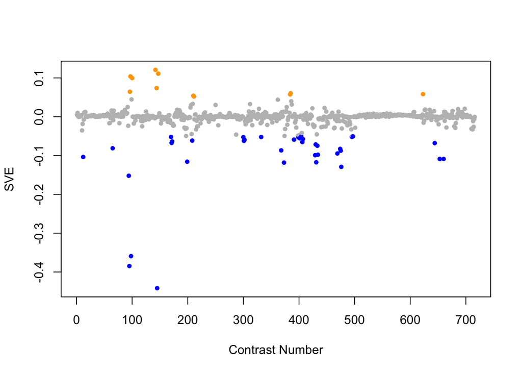

Positive SVE Contrasts:

|  | Contrast.Num | SVE | GEO.GSE | Cond.1 | Cond.2 | Mutation |
| --- | --- | --- | --- | --- | --- | --- |
| GSE50513.s2t1.vs.s1t1 | 142 | 0.12 | GSE50513 | L4440 PA14 - rep 1 | L4440 OP50 - rep 1 |  |
| GSE50513.s4t1.vs.s3t1 | 147 | 0.11 | GSE50513 | zip-2 PA14 - rep 1 | zip-2 OP50 - rep 1 |  |
| GSE5793.s3t1.vs.s2t1 | 97 | 0.10 | GSE5793 | Celegans_PA14_4hours_RepA | Celegans_OP50_4hours_RepA |  |
| GSE5793.s3t2.vs.s2t2 | 100 | 0.10 | GSE5793 | Celegans_PA14_8hours_RepA | Celegans_OP50_8hours_RepA |  |
| GSE50513.s4t1.vs.s1t1 | 144 | 0.07 | GSE50513 | zip-2 PA14 - rep 1 | L4440 OP50 - rep 1 |  |
| GSE5793.s3t1.vs.s1t1 | 96 | 0.06 | GSE5793 | Celegans_PA14_4hours_RepA | Celegans_gacA_4hours_RepA |  |
| GSE34026.s3t1.vs.s0t1 | 385 | 0.06 | GSE34026 | N2 exposed to CVD110, biological rep1 | N2 exposed to OP50(E.coli), biological rep1 |  |
| GSE20053.s1t1.vs.s0t1 | 623 | 0.06 | GSE20053 | C. elegans N2_Y. pestis KIM5_24h_Sample A | C. elegans N2_E. coli OP50_24h_Sample A |  |
| GSE34026.s4t1.vs.s0t1 | 384 | 0.06 | GSE34026 | N2 exposed to CVD109, biological rep1 | N2 exposed to OP50(E.coli), biological rep1 |  |
| GSE42689.s3t1.vs.s1t1 | 210 | 0.05 | GSE42689 | mlk-1 fasted 1 | mek-1 fasted 1 |  |
| GSE42689.s4t1.vs.s1t1 | 211 | 0.05 | GSE42689 | mlk-1 fed 1 | mek-1 fasted 1 |  |

Negative SVE Contrasts:

|  | Contrast.Num | SVE | GEO.GSE | Cond.1 | Cond.2 | Mutation |
| --- | --- | --- | --- | --- | --- | --- |
| GSE50513.s3t1.vs.s2t1 | 145 | -0.44 | GSE50513 | zip-2 OP50 - rep 1 | L4440 PA14 - rep 1 |  |
| GSE5793.s2t1.vs.s1t1 | 95 | -0.38 | GSE5793 | Celegans_OP50_4hours_RepA | Celegans_gacA_4hours_RepA |  |
| GSE5793.s2t2.vs.s1t2 | 98 | -0.36 | GSE5793 | Celegans_OP50_8hours_RepA | Celegans_gacA_8hours_RepA |  |
| GSE5801.s3t1.vs.s2t1 | 94 | -0.15 | GSE5801 | daf2pmk1_RepA | daf2daf16_RepA |  |
| GSE23528A.s1t6.vs.s1t1 | 476 | -0.13 | GSE23528 | Adult at T22 in LD, time-series experiment 3 | Adult at T2 in LD, time-series experiment 3 |  |
| GSE35354A.s1t3.vs.s1t1 | 373 | -0.12 | GSE35354 | Q100_rep1 | Q control_rep1 |  |
| GSE27677A.s3t2.vs.s3t1 | 431 | -0.12 | GSE27677 | daf-16, Fast , rep 1 | daf-16, Fed , rep 1 |  |
| GSE43959.s1t2.vs.s4t2 | 199 | -0.12 | GSE43959 | N2 gravid adult on E. coli OP50 rep 1 | N2 gravid adult on 1:1000 Comamonas DA1877 rep 1 |  |
| GSE15527.s2t1.vs.s1t1 | 660 | -0.11 | GSE15527 | sma-6 L4 worm, biological rep1 | dbl-1 L4 worm, biological rep1 | dbl-1 |
| GSE16405.s4t1.vs.s2t1 | 653 | -0.11 | GSE16405 | xpa-1_1 | nth-1_1 | nth-1 vs. xpa-1 |
| GSE9682.s1t2.vs.s0t2 | 12 | -0.10 | GSE9682 | N2-Cel-RhebRNAi-fed-biological rep1 | N2-controlRNAi-fed-biological rep1 | Rheb |
| GSE27677A.s2t1.vs.s0t1 | 429 | -0.10 | GSE27677 | jun-1, Fed , rep 1 | N2, Fed , rep 1 | 40694 |
| GSE27677A.s0t2.vs.s0t1 | 434 | -0.10 | GSE27677 | N2, Fast , rep 1 | N2, Fed , rep 1 |  |
| GSE23528A.s1t6.vs.s0t6 | 469 | -0.09 | GSE23528 | Adult at T22 in LD, time-series experiment 3 | Adult at T22, non-entrained control time-series experiment 4 |  |
| GSE23528A.s1t5.vs.s1t1 | 475 | -0.09 | GSE23528 | Adult at T18 in LD, time-series experiment 3 | Adult at T2 in LD, time-series experiment 3 |  |
| GSE35360A.s2t1.vs.s0t1 | 368 | -0.09 | GSE35360 | HF 11d_2.0_rep1 | HF 11d control_rep1 |  |
| GSE23528A.s1t4.vs.s1t1 | 474 | -0.08 | GSE23528 | Adult at T14 in LD, time-series experiment 3 | Adult at T2 in LD, time-series experiment 3 |  |
| GSE8659.s2t1.vs.s1t1 | 65 | -0.08 | GSE8659 | strain GR1373 replicate 1 | N2 replicate 1 | eri-1 |
| GSE27677A.s1t2.vs.s1t1 | 433 | -0.07 | GSE27677 | kgb-1, Fast , rep 1 | kgb-1, Fed , rep 1 |  |
| GSE27677A.s1t1.vs.s0t1 | 430 | -0.07 | GSE27677 | kgb-1, Fed , rep 1 | N2, Fed , rep 1 | kgb-1 |
| GSE16915.s1t1.vs.s3t1 | 644 | -0.07 | GSE16915 | control sample | bio-electrosprayed sample |  |
| GSE47778.s1t3.vs.s2t3 | 171 | -0.07 | GSE47778 | N2; UV; replicate 1 | daf-2; UV; replicate 1 | daf-2 |
| GSE30505.s2t1.vs.s3t1 | 406 | -0.07 | GSE30505 | L3 N2 (WT) ash-2 #1 | L3 glp-1 E.V. #1 | ash-2(RNAi) vs. glp-1 |
| GSE47778.s5t3.vs.s2t3 | 172 | -0.06 | GSE47778 | xpa-1 10mJ/cm2; replicate 1 | daf-2; UV; replicate 1 | xpa-1 vs. daf-2 |
| GSE41366C.s2t4.vs.s2t1 | 301 | -0.06 | GSE41366 | high_DDVP-continuous_expose-20h_harvest-rep1 | high_DDVP-continuous_expose-2h_harvest-rep1 |  |
| GSE42703.s2t2.vs.s2t1 | 208 | -0.06 | GSE42703 | WT incubated with H2O, biological rep1 | WT incubated with 1mM copper sulfate, biological rep1 |  |
| GSE41366C.s2t5.vs.s2t1 | 302 | -0.06 | GSE41366 | high_DDVP-continuous_expose-26h_harvest-rep1 | high_DDVP-continuous_expose-2h_harvest-rep1 |  |
| GSE32467.s1t1.vs.s0t1 | 391 | -0.06 | GSE32467 | unc-37(e262) A-class, biological rep1 | wildtype A-class, biological rep1 | unc-37 |
| GSE30505.s1t1.vs.s3t1 | 407 | -0.06 | GSE30505 | L3 N2 (WT) E.V. #1 | L3 glp-1 E.V. #1 | glp-1 |
| GSE30505.s1t2.vs.s3t2 | 401 | -0.06 | GSE30505 | Day 8 N2 (WT) E.V. #1 | Day 8 glp-1 E.V. #1 | glp-1 |
| GSE30505.s1t2.vs.s4t2 | 399 | -0.05 | GSE30505 | Day 8 N2 (WT) E.V. #1 | Day 8 glp-1 ash-2 #1 | glp-1; ash-2 |
| GSE41366C.s2t3.vs.s2t1 | 300 | -0.05 | GSE41366 | high_DDVP-continuous_expose-14h_harvest-rep1 | high_DDVP-continuous_expose-2h_harvest-rep1 |  |
| GSE38997.s2t2.vs.s1t2 | 332 | -0.05 | GSE38997 | experiment 4 EtBr-exposed samples at 24 h 4e24 | experiment 4 control samples at 24 h 4c24 |  |
| GSE47778.s4t3.vs.s2t3 | 170 | -0.05 | GSE47778 | daf-2;daf-16; UV; replicate 1 | daf-2; UV; replicate 1 | daf-2;daf-16 vs. daf-2 |
| GSE23528C.s1t4.vs.s1t1 | 495 | -0.05 | GSE23528 | Adult at T38 in DD, time-series experiment 2 | Adult at T26 in DD, time-series experiment 2 |  |
| GSE23528C.s1t6.vs.s1t1 | 497 | -0.05 | GSE23528 | Adult at T46 in DD, time-series experiment 2 | Adult at T26 in DD, time-series experiment 2 |  |
| GSE30505.s2t1.vs.s4t1 | 404 | -0.05 | GSE30505 | L3 N2 (WT) ash-2 #1 | L3 glp-1 ash-2 #1 | glp-1 |

$~$

$~$

#### GO Term Enrichment:

This analysis tests each hemi-module for enrichment of specific GO terms. Only gene-level annotations (e.g., as would be found on the gene’s page in Wormbase) are tested - the hierarchical structure of the GO ontology is not taken into account.

*Note: At least the top two most enriched terms from each GO domain (BP/MF/CC) are shown, even when not statistically significant.*

##### Enriched GO terms: Hemi-module A

| ID | GO.Term | GO Domain | Raw p-value | Adj p-value |
| --- | --- | --- | --- | --- |
| [GO_0045087](http://amigo.geneontology.org/amigo/term/GO:0045087) | innate immune response | BP | 1.18e-103 | 4.29e-100 |
| [GO_0050829](http://amigo.geneontology.org/amigo/term/GO:0050829) | defense response to Gram-negative bacterium | BP | 6.22e-11 | 1.13e-07 |
| [GO_0097501](http://amigo.geneontology.org/amigo/term/GO:0097501) | stress response to metal ion | BP | 5.68e-06 | 6.90e-03 |
| [GO_1990170](http://amigo.geneontology.org/amigo/term/GO:1990170) | stress response to cadmium ion | BP | 4.50e-05 | 4.09e-02 |
| [GO_0010332](http://amigo.geneontology.org/amigo/term/GO:0010332) | response to gamma radiation | BP | 7.34e-05 | 5.21e-02 |
| [GO_0030968](http://amigo.geneontology.org/amigo/term/GO:0030968) | endoplasmic reticulum unfolded protein response | BP | 8.87e-05 | 5.21e-02 |
| [GO_0036498](http://amigo.geneontology.org/amigo/term/GO:0036498) | IRE1-mediated unfolded protein response | BP | 1.00e-04 | 5.21e-02 |
| [GO_0030246](http://amigo.geneontology.org/amigo/term/GO:0030246) | carbohydrate binding | MF | 3.55e-08 | 7.26e-05 |
| [GO_0003723](http://amigo.geneontology.org/amigo/term/GO:0003723) | RNA binding | MF | 3.82e-04 | 3.29e-01 |
| [GO_0045121](http://amigo.geneontology.org/amigo/term/GO:0045121) | membrane raft | CC | 1.78e-12 | 1.65e-09 |
| [GO_0005634](http://amigo.geneontology.org/amigo/term/GO:0005634) | nucleus | CC | 3.37e-05 | 1.57e-02 |
| [GO_0005737](http://amigo.geneontology.org/amigo/term/GO:0005737) | cytoplasm | CC | 1.29e-04 | 4.00e-02 |
| [GO_0005739](http://amigo.geneontology.org/amigo/term/GO:0005739) | mitochondrion | CC | 3.80e-04 | 8.81e-02 |

##### Enriched GO terms: Hemi-module B

| ID | GO.Term | GO Domain | Raw p-value | Adj p-value |
| --- | --- | --- | --- | --- |
| [GO_0055114](http://amigo.geneontology.org/amigo/term/GO:0055114) | oxidation-reduction process | BP | 6.81e-09 | 2.48e-05 |
| [GO_0050830](http://amigo.geneontology.org/amigo/term/GO:0050830) | defense response to Gram-positive bacterium | BP | 9.62e-06 | 1.75e-02 |
| [GO_0009405](http://amigo.geneontology.org/amigo/term/GO:0009405) | pathogenesis | BP | 2.13e-05 | 1.94e-02 |
| [GO_0035915](http://amigo.geneontology.org/amigo/term/GO:0035915) | pore formation in membrane of other organism | BP | 2.13e-05 | 1.94e-02 |
| [GO_0019835](http://amigo.geneontology.org/amigo/term/GO:0019835) | cytolysis | BP | 1.27e-04 | 9.25e-02 |
| [GO_0016491](http://amigo.geneontology.org/amigo/term/GO:0016491) | oxidoreductase activity | MF | 1.05e-07 | 2.14e-04 |
| [GO_0016787](http://amigo.geneontology.org/amigo/term/GO:0016787) | hydrolase activity | MF | 6.97e-04 | 5.57e-01 |
| [GO_0005764](http://amigo.geneontology.org/amigo/term/GO:0005764) | lysosome | CC | 7.67e-05 | 5.89e-02 |
| [GO_0046930](http://amigo.geneontology.org/amigo/term/GO:0046930) | pore complex | CC | 1.27e-04 | 5.89e-02 |

$~$

$~$

#### Tissue Enrichment:

This analysis tests each hemi-module for enrichment of genes associated with anatomy terms. Negative enrichment scores indicate fewer hemi-module genes than expected by random chance were associated with the anatomy term in question.

##### Enriched tissues: Hemi-module A

| ID | Anatomy.Term | Definition | Raw p-value | Adj p-value |
| --- | --- | --- | --- | --- |
| [WBbt_0005772](https://wormbase.org/species/all/anatomy_term/WBbt:0005772) | intestine | A chain of very large cuboidal cells forming a wide central lumen in which food arrives from the posterior pharynx, is digested, and from which waste products proceed to the rectum. Intestinal rings f… | 5.08e-13 | 1.24e-09 |
| [WBbt_0005767](https://wormbase.org/species/all/anatomy_term/WBbt:0005767) | pharyngeal-intestinal valve | A group of six equivalent cells forms a tightly constructed ‘valve’ that links the posterior bulb of the pharynx to the anterior four cells of the intestine. These six cells comprise a small epithelia… | 1.85e-05 | 2.25e-02 |

##### Enriched tissues: Hemi-module B

| ID | Anatomy.Term | Definition | Raw p-value | Adj p-value |
| --- | --- | --- | --- | --- |
| [WBbt_0005772](https://wormbase.org/species/all/anatomy_term/WBbt:0005772) | intestine | A chain of very large cuboidal cells forming a wide central lumen in which food arrives from the posterior pharynx, is digested, and from which waste products proceed to the rectum. Intestinal rings f… | 3.91e-07 | 9.52e-04 |

$~$

$~$

#### HOMER promoter motif enrichment:

This analysis tests each hemi-module for enrichment of 108 known *C. elegans* transcription factor binding site motifs (see [108 CE motifs](https://katiepod.github.io//all.worm.motifs.html)) using the HOMER (Hypergeometric Optimization of Motif EnRichment) software (see [PMID:20513432](https://pubmed.ncbi.nlm.nih.gov/20513432)). HOMER was run using default parameters on sequences 1 kb upstream of the transcription start site.

##### Motif enrichment: Hemi-module A

Total target sequences = 377  
Total background sequences = 41614  
* - possible false positive

Rank

Motif

P-value

log P-pvalue

% of Targets

% of Background

STD(Bg STD)

Best Match/Details

Motif File

1

[figure not shown]

1e-56

-1.292e+02

42.44%

10.47%

274.9bp (327.7bp)

PQM-1(?)/cElegans-L3-ChIP-Seq(modEncode)/Homer(0.988)  
[More Information](https://katiepod.github.io/HomerResults/m200_a_hemi_genes.txt.out.1kb/homerResults/motif1.info.html) | [Similar Motifs Found](https://katiepod.github.io/HomerResults/m200_a_hemi_genes.txt.out.1kb/homerResults/motif1.similar.html)

[motif file (matrix)](https://katiepod.github.io/HomerResults/m200_a_hemi_genes.txt.out.1kb/homerResults/motif1.motif)

2

[figure not shown]

1e-17

-3.943e+01

27.59%

11.34%

272.1bp (316.3bp)

fos-1/MA1448.1/Jaspar(0.892)  
[More Information](https://katiepod.github.io/HomerResults/m200_a_hemi_genes.txt.out.1kb/homerResults/motif2.info.html) | [Similar Motifs Found](https://katiepod.github.io/HomerResults/m200_a_hemi_genes.txt.out.1kb/homerResults/motif2.similar.html)

[motif file (matrix)](https://katiepod.github.io/HomerResults/m200_a_hemi_genes.txt.out.1kb/homerResults/motif2.motif)

3

[figure not shown]

1e-14

-3.439e+01

25.73%

10.93%

262.2bp (317.1bp)

MF0009.1_TRP(MYB)_class/Jaspar(0.694)  
[More Information](https://katiepod.github.io/HomerResults/m200_a_hemi_genes.txt.out.1kb/homerResults/motif3.info.html) | [Similar Motifs Found](https://katiepod.github.io/HomerResults/m200_a_hemi_genes.txt.out.1kb/homerResults/motif3.similar.html)

[motif file (matrix)](https://katiepod.github.io/HomerResults/m200_a_hemi_genes.txt.out.1kb/homerResults/motif3.motif)

4

[figure not shown]

1e-14

-3.411e+01

14.85%

4.29%

263.2bp (319.9bp)

atf-7/MA1438.1/Jaspar(0.787)  
[More Information](https://katiepod.github.io/HomerResults/m200_a_hemi_genes.txt.out.1kb/homerResults/motif4.info.html) | [Similar Motifs Found](https://katiepod.github.io/HomerResults/m200_a_hemi_genes.txt.out.1kb/homerResults/motif4.similar.html)

[motif file (matrix)](https://katiepod.github.io/HomerResults/m200_a_hemi_genes.txt.out.1kb/homerResults/motif4.motif)

5 *

[figure not shown]

1e-11

-2.691e+01

7.43%

1.38%

226.7bp (311.9bp)

POL006.1_BREu/Jaspar(0.623)  
[More Information](https://katiepod.github.io/HomerResults/m200_a_hemi_genes.txt.out.1kb/homerResults/motif5.info.html) | [Similar Motifs Found](https://katiepod.github.io/HomerResults/m200_a_hemi_genes.txt.out.1kb/homerResults/motif5.similar.html)

[motif file (matrix)](https://katiepod.github.io/HomerResults/m200_a_hemi_genes.txt.out.1kb/homerResults/motif5.motif)

6 *

[figure not shown]

1e-11

-2.651e+01

30.50%

16.08%

277.9bp (309.3bp)

PL0017.1_hlh-2::hlh-10/Jaspar(0.746)  
[More Information](https://katiepod.github.io/HomerResults/m200_a_hemi_genes.txt.out.1kb/homerResults/motif6.info.html) | [Similar Motifs Found](https://katiepod.github.io/HomerResults/m200_a_hemi_genes.txt.out.1kb/homerResults/motif6.similar.html)

[motif file (matrix)](https://katiepod.github.io/HomerResults/m200_a_hemi_genes.txt.out.1kb/homerResults/motif6.motif)

7 *

[figure not shown]

1e-11

-2.565e+01

7.43%

1.46%

282.6bp (304.2bp)

MF0003.1_REL_class/Jaspar(0.606)  
[More Information](https://katiepod.github.io/HomerResults/m200_a_hemi_genes.txt.out.1kb/homerResults/motif7.info.html) | [Similar Motifs Found](https://katiepod.github.io/HomerResults/m200_a_hemi_genes.txt.out.1kb/homerResults/motif7.similar.html)

[motif file (matrix)](https://katiepod.github.io/HomerResults/m200_a_hemi_genes.txt.out.1kb/homerResults/motif7.motif)

8 *

[figure not shown]

1e-10

-2.451e+01

3.98%

0.35%

249.1bp (296.6bp)

nhr-6/MA1451.1/Jaspar(0.644)  
[More Information](https://katiepod.github.io/HomerResults/m200_a_hemi_genes.txt.out.1kb/homerResults/motif8.info.html) | [Similar Motifs Found](https://katiepod.github.io/HomerResults/m200_a_hemi_genes.txt.out.1kb/homerResults/motif8.similar.html)

[motif file (matrix)](https://katiepod.github.io/HomerResults/m200_a_hemi_genes.txt.out.1kb/homerResults/motif8.motif)

9 *

[figure not shown]

1e-10

-2.434e+01

1.86%

0.02%

107.3bp (252.4bp)

POL007.1_BREd/Jaspar(0.544)  
[More Information](https://katiepod.github.io/HomerResults/m200_a_hemi_genes.txt.out.1kb/homerResults/motif9.info.html) | [Similar Motifs Found](https://katiepod.github.io/HomerResults/m200_a_hemi_genes.txt.out.1kb/homerResults/motif9.similar.html)

[motif file (matrix)](https://katiepod.github.io/HomerResults/m200_a_hemi_genes.txt.out.1kb/homerResults/motif9.motif)

10 *

[figure not shown]

1e-10

-2.422e+01

3.71%

0.30%

271.4bp (313.9bp)

PHA-4(Forkhead)/cElegans-Embryos-PHA4-ChIP-Seq(modEncode)/Homer(0.638)  
[More Information](https://katiepod.github.io/HomerResults/m200_a_hemi_genes.txt.out.1kb/homerResults/motif10.info.html) | [Similar Motifs Found](https://katiepod.github.io/HomerResults/m200_a_hemi_genes.txt.out.1kb/homerResults/motif10.similar.html)

[motif file (matrix)](https://katiepod.github.io/HomerResults/m200_a_hemi_genes.txt.out.1kb/homerResults/motif10.motif)

11 *

[figure not shown]

1e-10

-2.343e+01

7.43%

1.62%

319.2bp (305.6bp)

skn-1/MA0547.1/Jaspar(0.742)  
[More Information](https://katiepod.github.io/HomerResults/m200_a_hemi_genes.txt.out.1kb/homerResults/motif11.info.html) | [Similar Motifs Found](https://katiepod.github.io/HomerResults/m200_a_hemi_genes.txt.out.1kb/homerResults/motif11.similar.html)

[motif file (matrix)](https://katiepod.github.io/HomerResults/m200_a_hemi_genes.txt.out.1kb/homerResults/motif11.motif)

12 *

[figure not shown]

1e-9

-2.270e+01

2.92%

0.17%

260.9bp (332.6bp)

ces-2/MA0922.1/Jaspar(0.637)  
[More Information](https://katiepod.github.io/HomerResults/m200_a_hemi_genes.txt.out.1kb/homerResults/motif12.info.html) | [Similar Motifs Found](https://katiepod.github.io/HomerResults/m200_a_hemi_genes.txt.out.1kb/homerResults/motif12.similar.html)

[motif file (matrix)](https://katiepod.github.io/HomerResults/m200_a_hemi_genes.txt.out.1kb/homerResults/motif12.motif)

13 *

[figure not shown]

1e-9

-2.089e+01

4.51%

0.63%

286.8bp (309.3bp)

fos-1/MA1448.1/Jaspar(0.710)  
[More Information](https://katiepod.github.io/HomerResults/m200_a_hemi_genes.txt.out.1kb/homerResults/motif13.info.html) | [Similar Motifs Found](https://katiepod.github.io/HomerResults/m200_a_hemi_genes.txt.out.1kb/homerResults/motif13.similar.html)

[motif file (matrix)](https://katiepod.github.io/HomerResults/m200_a_hemi_genes.txt.out.1kb/homerResults/motif13.motif)

14 *

[figure not shown]

1e-8

-2.049e+01

5.04%

0.83%

299.4bp (327.2bp)

PL0017.1_hlh-2::hlh-10/Jaspar(0.606)  
[More Information](https://katiepod.github.io/HomerResults/m200_a_hemi_genes.txt.out.1kb/homerResults/motif14.info.html) | [Similar Motifs Found](https://katiepod.github.io/HomerResults/m200_a_hemi_genes.txt.out.1kb/homerResults/motif14.similar.html)

[motif file (matrix)](https://katiepod.github.io/HomerResults/m200_a_hemi_genes.txt.out.1kb/homerResults/motif14.motif)

15 *

[figure not shown]

1e-8

-1.966e+01

4.77%

0.78%

266.0bp (297.8bp)

POL009.1_DCE_S_II/Jaspar(0.571)  
[More Information](https://katiepod.github.io/HomerResults/m200_a_hemi_genes.txt.out.1kb/homerResults/motif15.info.html) | [Similar Motifs Found](https://katiepod.github.io/HomerResults/m200_a_hemi_genes.txt.out.1kb/homerResults/motif15.similar.html)

[motif file (matrix)](https://katiepod.github.io/HomerResults/m200_a_hemi_genes.txt.out.1kb/homerResults/motif15.motif)

16 *

[figure not shown]

1e-8

-1.955e+01

41.11%

27.07%

284.1bp (315.3bp)

PHA-4(Forkhead)/cElegans-Embryos-PHA4-ChIP-Seq(modEncode)/Homer(0.885)  
[More Information](https://katiepod.github.io/HomerResults/m200_a_hemi_genes.txt.out.1kb/homerResults/motif16.info.html) | [Similar Motifs Found](https://katiepod.github.io/HomerResults/m200_a_hemi_genes.txt.out.1kb/homerResults/motif16.similar.html)

[motif file (matrix)](https://katiepod.github.io/HomerResults/m200_a_hemi_genes.txt.out.1kb/homerResults/motif16.motif)

17 *

[figure not shown]

1e-8

-1.946e+01

2.12%

0.08%

209.3bp (243.6bp)

unc-62/MA0918.1/Jaspar(0.610)  
[More Information](https://katiepod.github.io/HomerResults/m200_a_hemi_genes.txt.out.1kb/homerResults/motif17.info.html) | [Similar Motifs Found](https://katiepod.github.io/HomerResults/m200_a_hemi_genes.txt.out.1kb/homerResults/motif17.similar.html)

[motif file (matrix)](https://katiepod.github.io/HomerResults/m200_a_hemi_genes.txt.out.1kb/homerResults/motif17.motif)

18 *

[figure not shown]

1e-8

-1.935e+01

15.65%

6.85%

266.2bp (325.3bp)

MF0002.1_bZIP_CREB/G-box-like_subclass/Jaspar(0.619)  
[More Information](https://katiepod.github.io/HomerResults/m200_a_hemi_genes.txt.out.1kb/homerResults/motif18.info.html) | [Similar Motifs Found](https://katiepod.github.io/HomerResults/m200_a_hemi_genes.txt.out.1kb/homerResults/motif18.similar.html)

[motif file (matrix)](https://katiepod.github.io/HomerResults/m200_a_hemi_genes.txt.out.1kb/homerResults/motif18.motif)

19 *

[figure not shown]

1e-8

-1.854e+01

8.22%

2.44%

291.8bp (303.6bp)

lin-54/MA1450.1/Jaspar(0.600)  
[More Information](https://katiepod.github.io/HomerResults/m200_a_hemi_genes.txt.out.1kb/homerResults/motif19.info.html) | [Similar Motifs Found](https://katiepod.github.io/HomerResults/m200_a_hemi_genes.txt.out.1kb/homerResults/motif19.similar.html)

[motif file (matrix)](https://katiepod.github.io/HomerResults/m200_a_hemi_genes.txt.out.1kb/homerResults/motif19.motif)

20 *

[figure not shown]

1e-8

-1.850e+01

17.51%

8.31%

296.2bp (313.8bp)

fkh-9/MA1440.1/Jaspar(0.550)  
[More Information](https://katiepod.github.io/HomerResults/m200_a_hemi_genes.txt.out.1kb/homerResults/motif20.info.html) | [Similar Motifs Found](https://katiepod.github.io/HomerResults/m200_a_hemi_genes.txt.out.1kb/homerResults/motif20.similar.html)

[motif file (matrix)](https://katiepod.github.io/HomerResults/m200_a_hemi_genes.txt.out.1kb/homerResults/motif20.motif)

21 *

[figure not shown]

1e-7

-1.819e+01

2.65%

0.20%

220.2bp (325.7bp)

MF0011.1_HMG_class/Jaspar(0.715)  
[More Information](https://katiepod.github.io/HomerResults/m200_a_hemi_genes.txt.out.1kb/homerResults/motif21.info.html) | [Similar Motifs Found](https://katiepod.github.io/HomerResults/m200_a_hemi_genes.txt.out.1kb/homerResults/motif21.similar.html)

[motif file (matrix)](https://katiepod.github.io/HomerResults/m200_a_hemi_genes.txt.out.1kb/homerResults/motif21.motif)

22 *

[figure not shown]

1e-7

-1.766e+01

6.37%

1.59%

276.4bp (309.3bp)

cebp-1/MA1444.1/Jaspar(0.829)  
[More Information](https://katiepod.github.io/HomerResults/m200_a_hemi_genes.txt.out.1kb/homerResults/motif22.info.html) | [Similar Motifs Found](https://katiepod.github.io/HomerResults/m200_a_hemi_genes.txt.out.1kb/homerResults/motif22.similar.html)

[motif file (matrix)](https://katiepod.github.io/HomerResults/m200_a_hemi_genes.txt.out.1kb/homerResults/motif22.motif)

23 *

[figure not shown]

1e-7

-1.727e+01

1.06%

0.00%

228.1bp (148.4bp)

dpy-27/MA0540.1/Jaspar(0.594)  
[More Information](https://katiepod.github.io/HomerResults/m200_a_hemi_genes.txt.out.1kb/homerResults/motif23.info.html) | [Similar Motifs Found](https://katiepod.github.io/HomerResults/m200_a_hemi_genes.txt.out.1kb/homerResults/motif23.similar.html)

[motif file (matrix)](https://katiepod.github.io/HomerResults/m200_a_hemi_genes.txt.out.1kb/homerResults/motif23.motif)

24 *

[figure not shown]

1e-7

-1.674e+01

4.24%

0.74%

268.0bp (294.5bp)

unc-62/MA0918.1/Jaspar(0.585)  
[More Information](https://katiepod.github.io/HomerResults/m200_a_hemi_genes.txt.out.1kb/homerResults/motif24.info.html) | [Similar Motifs Found](https://katiepod.github.io/HomerResults/m200_a_hemi_genes.txt.out.1kb/homerResults/motif24.similar.html)

[motif file (matrix)](https://katiepod.github.io/HomerResults/m200_a_hemi_genes.txt.out.1kb/homerResults/motif24.motif)

25 *

[figure not shown]

1e-7

-1.656e+01

3.98%

0.66%

328.0bp (324.2bp)

POL012.1_TATA-Box/Jaspar(0.570)  
[More Information](https://katiepod.github.io/HomerResults/m200_a_hemi_genes.txt.out.1kb/homerResults/motif25.info.html) | [Similar Motifs Found](https://katiepod.github.io/HomerResults/m200_a_hemi_genes.txt.out.1kb/homerResults/motif25.similar.html)

[motif file (matrix)](https://katiepod.github.io/HomerResults/m200_a_hemi_genes.txt.out.1kb/homerResults/motif25.motif)

26 *

[figure not shown]

1e-7

-1.618e+01

5.57%

1.35%

283.2bp (298.2bp)

lin-14/MA0261.1/Jaspar(0.584)  
[More Information](https://katiepod.github.io/HomerResults/m200_a_hemi_genes.txt.out.1kb/homerResults/motif26.info.html) | [Similar Motifs Found](https://katiepod.github.io/HomerResults/m200_a_hemi_genes.txt.out.1kb/homerResults/motif26.similar.html)

[motif file (matrix)](https://katiepod.github.io/HomerResults/m200_a_hemi_genes.txt.out.1kb/homerResults/motif26.motif)

27 *

[figure not shown]

1e-6

-1.507e+01

46.15%

33.52%

282.2bp (318.0bp)

POL012.1_TATA-Box/Jaspar(0.701)  
[More Information](https://katiepod.github.io/HomerResults/m200_a_hemi_genes.txt.out.1kb/homerResults/motif27.info.html) | [Similar Motifs Found](https://katiepod.github.io/HomerResults/m200_a_hemi_genes.txt.out.1kb/homerResults/motif27.similar.html)

[motif file (matrix)](https://katiepod.github.io/HomerResults/m200_a_hemi_genes.txt.out.1kb/homerResults/motif27.motif)

28 *

[figure not shown]

1e-6

-1.486e+01

6.10%

1.73%

279.7bp (290.9bp)

snpc-4/MA0544.1/Jaspar(0.823)  
[More Information](https://katiepod.github.io/HomerResults/m200_a_hemi_genes.txt.out.1kb/homerResults/motif28.info.html) | [Similar Motifs Found](https://katiepod.github.io/HomerResults/m200_a_hemi_genes.txt.out.1kb/homerResults/motif28.similar.html)

[motif file (matrix)](https://katiepod.github.io/HomerResults/m200_a_hemi_genes.txt.out.1kb/homerResults/motif28.motif)

29 *

[figure not shown]

1e-5

-1.293e+01

13.79%

6.95%

310.7bp (310.1bp)

MF0002.1_bZIP_CREB/G-box-like_subclass/Jaspar(0.833)  
[More Information](https://katiepod.github.io/HomerResults/m200_a_hemi_genes.txt.out.1kb/homerResults/motif29.info.html) | [Similar Motifs Found](https://katiepod.github.io/HomerResults/m200_a_hemi_genes.txt.out.1kb/homerResults/motif29.similar.html)

[motif file (matrix)](https://katiepod.github.io/HomerResults/m200_a_hemi_genes.txt.out.1kb/homerResults/motif29.motif)

30 *

[figure not shown]

1e-3

-9.063e+00

9.55%

4.86%

277.7bp (303.8bp)

POL002.1_INR/Jaspar(0.609)  
[More Information](https://katiepod.github.io/HomerResults/m200_a_hemi_genes.txt.out.1kb/homerResults/motif30.info.html) | [Similar Motifs Found](https://katiepod.github.io/HomerResults/m200_a_hemi_genes.txt.out.1kb/homerResults/motif30.similar.html)

[motif file (matrix)](https://katiepod.github.io/HomerResults/m200_a_hemi_genes.txt.out.1kb/homerResults/motif30.motif)

##### Motif enrichment: Hemi-module B

Total target sequences = 67  
Total background sequences = 39512  
* - possible false positive

Rank

Motif

P-value

log P-pvalue

% of Targets

% of Background

STD(Bg STD)

Best Match/Details

Motif File

1

[figure not shown]

1e-20

-4.759e+01

61.19%

12.00%

276.9bp (312.3bp)

elt-3/MA0542.1/Jaspar(0.938)  
[More Information](https://katiepod.github.io/HomerResults/m200_b_hemi_genes.txt.out.1kb/homerResults/motif1.info.html) | [Similar Motifs Found](https://katiepod.github.io/HomerResults/m200_b_hemi_genes.txt.out.1kb/homerResults/motif1.similar.html)

[motif file (matrix)](https://katiepod.github.io/HomerResults/m200_b_hemi_genes.txt.out.1kb/homerResults/motif1.motif)

2 *

[figure not shown]

1e-10

-2.363e+01

28.36%

4.39%

196.6bp (304.3bp)

pqm-1/MA1703.1/Jaspar(0.640)  
[More Information](https://katiepod.github.io/HomerResults/m200_b_hemi_genes.txt.out.1kb/homerResults/motif2.info.html) | [Similar Motifs Found](https://katiepod.github.io/HomerResults/m200_b_hemi_genes.txt.out.1kb/homerResults/motif2.similar.html)

[motif file (matrix)](https://katiepod.github.io/HomerResults/m200_b_hemi_genes.txt.out.1kb/homerResults/motif2.motif)

3 *

[figure not shown]

1e-9

-2.288e+01

11.94%

0.34%

306.0bp (318.6bp)

MF0010.1_Homeobox_class/Jaspar(0.655)  
[More Information](https://katiepod.github.io/HomerResults/m200_b_hemi_genes.txt.out.1kb/homerResults/motif3.info.html) | [Similar Motifs Found](https://katiepod.github.io/HomerResults/m200_b_hemi_genes.txt.out.1kb/homerResults/motif3.similar.html)

[motif file (matrix)](https://katiepod.github.io/HomerResults/m200_b_hemi_genes.txt.out.1kb/homerResults/motif3.motif)

4 *

[figure not shown]

1e-9

-2.175e+01

8.96%

0.12%

173.5bp (333.1bp)

MF0011.1_HMG_class/Jaspar(0.528)  
[More Information](https://katiepod.github.io/HomerResults/m200_b_hemi_genes.txt.out.1kb/homerResults/motif4.info.html) | [Similar Motifs Found](https://katiepod.github.io/HomerResults/m200_b_hemi_genes.txt.out.1kb/homerResults/motif4.similar.html)

[motif file (matrix)](https://katiepod.github.io/HomerResults/m200_b_hemi_genes.txt.out.1kb/homerResults/motif4.motif)

5 *

[figure not shown]

1e-9

-2.170e+01

14.93%

0.86%

337.3bp (286.5bp)

efl-1/MA0541.1/Jaspar(0.562)  
[More Information](https://katiepod.github.io/HomerResults/m200_b_hemi_genes.txt.out.1kb/homerResults/motif5.info.html) | [Similar Motifs Found](https://katiepod.github.io/HomerResults/m200_b_hemi_genes.txt.out.1kb/homerResults/motif5.similar.html)

[motif file (matrix)](https://katiepod.github.io/HomerResults/m200_b_hemi_genes.txt.out.1kb/homerResults/motif5.motif)

6 *

[figure not shown]

1e-9

-2.157e+01

22.39%

2.78%

269.2bp (286.1bp)

SD0003.1_at_AC_acceptor/Jaspar(0.555)  
[More Information](https://katiepod.github.io/HomerResults/m200_b_hemi_genes.txt.out.1kb/homerResults/motif6.info.html) | [Similar Motifs Found](https://katiepod.github.io/HomerResults/m200_b_hemi_genes.txt.out.1kb/homerResults/motif6.similar.html)

[motif file (matrix)](https://katiepod.github.io/HomerResults/m200_b_hemi_genes.txt.out.1kb/homerResults/motif6.motif)

7 *

[figure not shown]

1e-9

-2.099e+01

7.46%

0.06%

247.6bp (328.4bp)

SD0001.1_at_AC_acceptor/Jaspar(0.558)  
[More Information](https://katiepod.github.io/HomerResults/m200_b_hemi_genes.txt.out.1kb/homerResults/motif7.info.html) | [Similar Motifs Found](https://katiepod.github.io/HomerResults/m200_b_hemi_genes.txt.out.1kb/homerResults/motif7.similar.html)

[motif file (matrix)](https://katiepod.github.io/HomerResults/m200_b_hemi_genes.txt.out.1kb/homerResults/motif7.motif)

8 *

[figure not shown]

1e-9

-2.096e+01

8.96%

0.14%

237.2bp (324.9bp)

PL0012.1_hlh-2::hlh-8/Jaspar(0.668)  
[More Information](https://katiepod.github.io/HomerResults/m200_b_hemi_genes.txt.out.1kb/homerResults/motif8.info.html) | [Similar Motifs Found](https://katiepod.github.io/HomerResults/m200_b_hemi_genes.txt.out.1kb/homerResults/motif8.similar.html)

[motif file (matrix)](https://katiepod.github.io/HomerResults/m200_b_hemi_genes.txt.out.1kb/homerResults/motif8.motif)

9 *

[figure not shown]

1e-8

-2.039e+01

10.45%

0.28%

165.4bp (287.3bp)

PL0005.1_hlh-30/Jaspar(0.656)  
[More Information](https://katiepod.github.io/HomerResults/m200_b_hemi_genes.txt.out.1kb/homerResults/motif9.info.html) | [Similar Motifs Found](https://katiepod.github.io/HomerResults/m200_b_hemi_genes.txt.out.1kb/homerResults/motif9.similar.html)

[motif file (matrix)](https://katiepod.github.io/HomerResults/m200_b_hemi_genes.txt.out.1kb/homerResults/motif9.motif)

10 *

[figure not shown]

1e-8

-2.028e+01

5.97%

0.02%

274.0bp (178.8bp)

MF0007.1_bHLH(zip)_class/Jaspar(0.644)  
[More Information](https://katiepod.github.io/HomerResults/m200_b_hemi_genes.txt.out.1kb/homerResults/motif10.info.html) | [Similar Motifs Found](https://katiepod.github.io/HomerResults/m200_b_hemi_genes.txt.out.1kb/homerResults/motif10.similar.html)

[motif file (matrix)](https://katiepod.github.io/HomerResults/m200_b_hemi_genes.txt.out.1kb/homerResults/motif10.motif)

11 *

[figure not shown]

1e-8

-1.991e+01

13.43%

0.74%

285.4bp (304.8bp)

POL008.1_DCE_S_I/Jaspar(0.494)  
[More Information](https://katiepod.github.io/HomerResults/m200_b_hemi_genes.txt.out.1kb/homerResults/motif11.info.html) | [Similar Motifs Found](https://katiepod.github.io/HomerResults/m200_b_hemi_genes.txt.out.1kb/homerResults/motif11.similar.html)

[motif file (matrix)](https://katiepod.github.io/HomerResults/m200_b_hemi_genes.txt.out.1kb/homerResults/motif11.motif)

12 *

[figure not shown]

1e-8

-1.935e+01

10.45%

0.33%

296.0bp (308.8bp)

LIN-39(Homeobox)/cElegans.L3-LIN39-ChIP-Seq(modEncode)/Homer(0.536)  
[More Information](https://katiepod.github.io/HomerResults/m200_b_hemi_genes.txt.out.1kb/homerResults/motif12.info.html) | [Similar Motifs Found](https://katiepod.github.io/HomerResults/m200_b_hemi_genes.txt.out.1kb/homerResults/motif12.similar.html)

[motif file (matrix)](https://katiepod.github.io/HomerResults/m200_b_hemi_genes.txt.out.1kb/homerResults/motif12.motif)

13 *

[figure not shown]

1e-8

-1.870e+01

13.43%

0.86%

288.0bp (302.2bp)

SD0002.1_at_AC_acceptor/Jaspar(0.588)  
[More Information](https://katiepod.github.io/HomerResults/m200_b_hemi_genes.txt.out.1kb/homerResults/motif13.info.html) | [Similar Motifs Found](https://katiepod.github.io/HomerResults/m200_b_hemi_genes.txt.out.1kb/homerResults/motif13.similar.html)

[motif file (matrix)](https://katiepod.github.io/HomerResults/m200_b_hemi_genes.txt.out.1kb/homerResults/motif13.motif)

14 *

[figure not shown]

1e-7

-1.821e+01

22.39%

3.57%

317.8bp (301.6bp)

POL008.1_DCE_S_I/Jaspar(0.594)  
[More Information](https://katiepod.github.io/HomerResults/m200_b_hemi_genes.txt.out.1kb/homerResults/motif14.info.html) | [Similar Motifs Found](https://katiepod.github.io/HomerResults/m200_b_hemi_genes.txt.out.1kb/homerResults/motif14.similar.html)

[motif file (matrix)](https://katiepod.github.io/HomerResults/m200_b_hemi_genes.txt.out.1kb/homerResults/motif14.motif)

15 *

[figure not shown]

1e-7

-1.820e+01

16.42%

1.62%

303.1bp (290.1bp)

unc-30/MA1443.1/Jaspar(0.518)  
[More Information](https://katiepod.github.io/HomerResults/m200_b_hemi_genes.txt.out.1kb/homerResults/motif15.info.html) | [Similar Motifs Found](https://katiepod.github.io/HomerResults/m200_b_hemi_genes.txt.out.1kb/homerResults/motif15.similar.html)

[motif file (matrix)](https://katiepod.github.io/HomerResults/m200_b_hemi_genes.txt.out.1kb/homerResults/motif15.motif)

16 *

[figure not shown]

1e-7

-1.786e+01

5.97%

0.03%

204.7bp (327.0bp)

POL009.1_DCE_S_II/Jaspar(0.578)  
[More Information](https://katiepod.github.io/HomerResults/m200_b_hemi_genes.txt.out.1kb/homerResults/motif16.info.html) | [Similar Motifs Found](https://katiepod.github.io/HomerResults/m200_b_hemi_genes.txt.out.1kb/homerResults/motif16.similar.html)

[motif file (matrix)](https://katiepod.github.io/HomerResults/m200_b_hemi_genes.txt.out.1kb/homerResults/motif16.motif)

17 *

[figure not shown]

1e-7

-1.739e+01

11.94%

0.70%

314.9bp (329.4bp)

POL012.1_TATA-Box/Jaspar(0.790)  
[More Information](https://katiepod.github.io/HomerResults/m200_b_hemi_genes.txt.out.1kb/homerResults/motif17.info.html) | [Similar Motifs Found](https://katiepod.github.io/HomerResults/m200_b_hemi_genes.txt.out.1kb/homerResults/motif17.similar.html)

[motif file (matrix)](https://katiepod.github.io/HomerResults/m200_b_hemi_genes.txt.out.1kb/homerResults/motif17.motif)

18 *

[figure not shown]

1e-7

-1.735e+01

13.43%

1.01%

289.3bp (298.8bp)

nhr-6/MA1451.1/Jaspar(0.570)  
[More Information](https://katiepod.github.io/HomerResults/m200_b_hemi_genes.txt.out.1kb/homerResults/motif18.info.html) | [Similar Motifs Found](https://katiepod.github.io/HomerResults/m200_b_hemi_genes.txt.out.1kb/homerResults/motif18.similar.html)

[motif file (matrix)](https://katiepod.github.io/HomerResults/m200_b_hemi_genes.txt.out.1kb/homerResults/motif18.motif)

19 *

[figure not shown]

1e-7

-1.621e+01

14.93%

1.54%

287.8bp (294.3bp)

MF0010.1_Homeobox_class/Jaspar(0.680)  
[More Information](https://katiepod.github.io/HomerResults/m200_b_hemi_genes.txt.out.1kb/homerResults/motif19.info.html) | [Similar Motifs Found](https://katiepod.github.io/HomerResults/m200_b_hemi_genes.txt.out.1kb/homerResults/motif19.similar.html)

[motif file (matrix)](https://katiepod.github.io/HomerResults/m200_b_hemi_genes.txt.out.1kb/homerResults/motif19.motif)

20 *

[figure not shown]

1e-6

-1.600e+01

13.43%

1.18%

252.2bp (307.3bp)

unc-62/MA0918.1/Jaspar(0.620)  
[More Information](https://katiepod.github.io/HomerResults/m200_b_hemi_genes.txt.out.1kb/homerResults/motif20.info.html) | [Similar Motifs Found](https://katiepod.github.io/HomerResults/m200_b_hemi_genes.txt.out.1kb/homerResults/motif20.similar.html)

[motif file (matrix)](https://katiepod.github.io/HomerResults/m200_b_hemi_genes.txt.out.1kb/homerResults/motif20.motif)

21 *

[figure not shown]

1e-6

-1.587e+01

5.97%

0.06%

125.5bp (220.1bp)

PHA-4(Forkhead)/cElegans-Embryos-PHA4-ChIP-Seq(modEncode)/Homer(0.640)  
[More Information](https://katiepod.github.io/HomerResults/m200_b_hemi_genes.txt.out.1kb/homerResults/motif21.info.html) | [Similar Motifs Found](https://katiepod.github.io/HomerResults/m200_b_hemi_genes.txt.out.1kb/homerResults/motif21.similar.html)

[motif file (matrix)](https://katiepod.github.io/HomerResults/m200_b_hemi_genes.txt.out.1kb/homerResults/motif21.motif)

22 *

[figure not shown]

1e-6

-1.555e+01

7.46%

0.18%

274.9bp (292.3bp)

elt-6/MA1439.1/Jaspar(0.666)  
[More Information](https://katiepod.github.io/HomerResults/m200_b_hemi_genes.txt.out.1kb/homerResults/motif22.info.html) | [Similar Motifs Found](https://katiepod.github.io/HomerResults/m200_b_hemi_genes.txt.out.1kb/homerResults/motif22.similar.html)

[motif file (matrix)](https://katiepod.github.io/HomerResults/m200_b_hemi_genes.txt.out.1kb/homerResults/motif22.motif)

23 *

[figure not shown]

1e-6

-1.517e+01

4.48%

0.01%

84.9bp (110.5bp)

nhr-6/MA1451.1/Jaspar(0.619)  
[More Information](https://katiepod.github.io/HomerResults/m200_b_hemi_genes.txt.out.1kb/homerResults/motif23.info.html) | [Similar Motifs Found](https://katiepod.github.io/HomerResults/m200_b_hemi_genes.txt.out.1kb/homerResults/motif23.similar.html)

[motif file (matrix)](https://katiepod.github.io/HomerResults/m200_b_hemi_genes.txt.out.1kb/homerResults/motif23.motif)

24 *

[figure not shown]

1e-6

-1.477e+01

4.48%

0.02%

306.0bp (281.9bp)

MF0011.1_HMG_class/Jaspar(0.640)  
[More Information](https://katiepod.github.io/HomerResults/m200_b_hemi_genes.txt.out.1kb/homerResults/motif24.info.html) | [Similar Motifs Found](https://katiepod.github.io/HomerResults/m200_b_hemi_genes.txt.out.1kb/homerResults/motif24.similar.html)

[motif file (matrix)](https://katiepod.github.io/HomerResults/m200_b_hemi_genes.txt.out.1kb/homerResults/motif24.motif)

25 *

[figure not shown]

1e-5

-1.346e+01

10.45%

0.81%

263.6bp (314.3bp)

ceh-22/MA0264.1/Jaspar(0.622)  
[More Information](https://katiepod.github.io/HomerResults/m200_b_hemi_genes.txt.out.1kb/homerResults/motif25.info.html) | [Similar Motifs Found](https://katiepod.github.io/HomerResults/m200_b_hemi_genes.txt.out.1kb/homerResults/motif25.similar.html)

[motif file (matrix)](https://katiepod.github.io/HomerResults/m200_b_hemi_genes.txt.out.1kb/homerResults/motif25.motif)

26 *

[figure not shown]

1e-5

-1.282e+01

14.93%

2.25%

290.9bp (299.0bp)

hlh-1/MA0545.1/Jaspar(0.584)  
[More Information](https://katiepod.github.io/HomerResults/m200_b_hemi_genes.txt.out.1kb/homerResults/motif26.info.html) | [Similar Motifs Found](https://katiepod.github.io/HomerResults/m200_b_hemi_genes.txt.out.1kb/homerResults/motif26.similar.html)

[motif file (matrix)](https://katiepod.github.io/HomerResults/m200_b_hemi_genes.txt.out.1kb/homerResults/motif26.motif)

27 *

[figure not shown]

1e-5

-1.191e+01

5.97%

0.17%

360.9bp (295.6bp)

POL011.1_XCPE1/Jaspar(0.527)  
[More Information](https://katiepod.github.io/HomerResults/m200_b_hemi_genes.txt.out.1kb/homerResults/motif27.info.html) | [Similar Motifs Found](https://katiepod.github.io/HomerResults/m200_b_hemi_genes.txt.out.1kb/homerResults/motif27.similar.html)

[motif file (matrix)](https://katiepod.github.io/HomerResults/m200_b_hemi_genes.txt.out.1kb/homerResults/motif27.motif)

28 *

[figure not shown]

1e-4

-1.148e+01

23.88%

6.91%

302.2bp (302.1bp)

POL013.1_MED-1/Jaspar(0.631)  
[More Information](https://katiepod.github.io/HomerResults/m200_b_hemi_genes.txt.out.1kb/homerResults/motif28.info.html) | [Similar Motifs Found](https://katiepod.github.io/HomerResults/m200_b_hemi_genes.txt.out.1kb/homerResults/motif28.similar.html)

[motif file (matrix)](https://katiepod.github.io/HomerResults/m200_b_hemi_genes.txt.out.1kb/homerResults/motif28.motif)

29 *

[figure not shown]

1e-4

-1.034e+01

17.91%

4.38%

242.7bp (312.2bp)

sma-4/MA0925.1/Jaspar(0.575)  
[More Information](https://katiepod.github.io/HomerResults/m200_b_hemi_genes.txt.out.1kb/homerResults/motif29.info.html) | [Similar Motifs Found](https://katiepod.github.io/HomerResults/m200_b_hemi_genes.txt.out.1kb/homerResults/motif29.similar.html)

[motif file (matrix)](https://katiepod.github.io/HomerResults/m200_b_hemi_genes.txt.out.1kb/homerResults/motif29.motif)

30 *

[figure not shown]

1e-3

-8.062e+00

14.93%

3.98%

349.5bp (315.6bp)

POL006.1_BREu/Jaspar(0.538)  
[More Information](https://katiepod.github.io/HomerResults/m200_b_hemi_genes.txt.out.1kb/homerResults/motif30.info.html) | [Similar Motifs Found](https://katiepod.github.io/HomerResults/m200_b_hemi_genes.txt.out.1kb/homerResults/motif30.similar.html)

[motif file (matrix)](https://katiepod.github.io/HomerResults/m200_b_hemi_genes.txt.out.1kb/homerResults/motif30.motif)

31 *

[figure not shown]

1e-2

-6.862e+00

10.45%

2.36%

298.7bp (275.5bp)

EFL-1(E2F)/cElegans-L1-EFL1-ChIP-Seq(modEncode)/Homer(0.747)  
[More Information](https://katiepod.github.io/HomerResults/m200_b_hemi_genes.txt.out.1kb/homerResults/motif31.info.html) | [Similar Motifs Found](https://katiepod.github.io/HomerResults/m200_b_hemi_genes.txt.out.1kb/homerResults/motif31.similar.html)

[motif file (matrix)](https://katiepod.github.io/HomerResults/m200_b_hemi_genes.txt.out.1kb/homerResults/motif31.motif)

32 *

[figure not shown]

1e-2

-5.428e+00

2.99%

0.14%

115.6bp (254.1bp)

fkh-9/MA1440.1/Jaspar(0.600)  
[More Information](https://katiepod.github.io/HomerResults/m200_b_hemi_genes.txt.out.1kb/homerResults/motif32.info.html) | [Similar Motifs Found](https://katiepod.github.io/HomerResults/m200_b_hemi_genes.txt.out.1kb/homerResults/motif32.similar.html)

[motif file (matrix)](https://katiepod.github.io/HomerResults/m200_b_hemi_genes.txt.out.1kb/homerResults/motif32.motif)

33 *

[figure not shown]

1e-2

-4.936e+00

22.39%

11.32%

225.7bp (298.5bp)

ceh-28/MA1445.1/Jaspar(0.729)  
[More Information](https://katiepod.github.io/HomerResults/m200_b_hemi_genes.txt.out.1kb/homerResults/motif33.info.html) | [Similar Motifs Found](https://katiepod.github.io/HomerResults/m200_b_hemi_genes.txt.out.1kb/homerResults/motif33.similar.html)

[motif file (matrix)](https://katiepod.github.io/HomerResults/m200_b_hemi_genes.txt.out.1kb/homerResults/motif33.motif)

34 *

[figure not shown]

1e-1

-3.956e+00

2.99%

0.31%

140.2bp (264.8bp)

MF0011.1_HMG_class/Jaspar(0.744)  
[More Information](https://katiepod.github.io/HomerResults/m200_b_hemi_genes.txt.out.1kb/homerResults/motif34.info.html) | [Similar Motifs Found](https://katiepod.github.io/HomerResults/m200_b_hemi_genes.txt.out.1kb/homerResults/motif34.similar.html)

[motif file (matrix)](https://katiepod.github.io/HomerResults/m200_b_hemi_genes.txt.out.1kb/homerResults/motif34.motif)

$~$

$~$

#### Promoter Word Enrichment:

This analysis tests each hemi-module for enrichment of specific promoter words. The list of promoter words tested was generated by running the MobyDick algorithm (see [PMID:10944202](https://pubmed.ncbi.nlm.nih.gov/10944202)) on the full set of *C. elegans* 2 Kbp promoters.

##### Enriched promoter words: Hemi-module A

| Word | RC | Raw.p.value | Adj.p.value |
| --- | --- | --- | --- |
| TTATCA | TGATAA | 2.31e-18 | 7.02e-15 |
| TTATCAGT | ACTGATAA | 2.69e-18 | 7.02e-15 |
| CTTATCAGT | ACTGATAAG | 7.72e-18 | 1.35e-14 |
| TCTTATCA | TGATAAGA | 1.13e-16 | 1.47e-13 |
| TTATCAG | CTGATAA | 1.42e-15 | 1.48e-12 |
| ACTGATA | TATCAGT | 3.60e-15 | 3.14e-12 |
| ACTGATAA | TTATCAGT | 4.41e-14 | 3.29e-11 |
| CTTATC | GATAAG | 6.43e-14 | 4.21e-11 |
| CTGATAA | TTATCAG | 3.37e-13 | 1.96e-10 |
| TTCTTATCA | TGATAAGAA | 5.29e-12 | 2.77e-09 |
| TCTTATC | GATAAGA | 1.98e-11 | 9.43e-09 |
| TTTCTTATC | GATAAGAAA | 1.27e-10 | 5.52e-08 |
| TGATAA | TTATCA | 2.06e-10 | 8.28e-08 |
| CTGATAAG | CTTATCAG | 5.02e-10 | 1.87e-07 |
| CTGATA | TATCAG | 2.15e-09 | 7.14e-07 |
| TTATCAGTT | AACTGATAA | 2.18e-09 | 7.14e-07 |
| ACTGATAAC | GTTATCAGT | 3.94e-09 | 1.21e-06 |
| GATAAGA | TCTTATC | 5.43e-09 | 1.58e-06 |
| ACTGATAAG | CTTATCAGT | 1.20e-08 | 3.31e-06 |
| TATCA | TGATA | 2.84e-08 | 7.43e-06 |
| TGATAAGA | TCTTATCA | 4.95e-08 | 1.23e-05 |
| ACTGATAAGA | TCTTATCAGT | 4.20e-07 | 9.97e-05 |
| AACTGATAA | TTATCAGTT | 5.19e-07 | 1.18e-04 |
| ATCAGT | ACTGAT | 9.16e-07 | 2.00e-04 |
| TCCTTATC | GATAAGGA | 1.31e-06 | 2.73e-04 |
| ACTGAT | ATCAGT | 2.79e-06 | 5.61e-04 |
| CCTTATC | GATAAGG | 8.03e-06 | 1.56e-03 |
| TTATCACT | AGTGATAA | 1.45e-05 | 2.71e-03 |
| TTATCAA | TTGATAA | 1.80e-05 | 3.12e-03 |
| GATAACA | TGTTATC | 1.81e-05 | 3.12e-03 |
| ACGTCAT | ATGACGT | 1.85e-05 | 3.12e-03 |
| CTTATCAC | GTGATAAG | 2.58e-05 | 4.22e-03 |
| TCTTAT | ATAAGA | 2.80e-05 | 4.43e-03 |
| GTTATC | GATAAC | 3.05e-05 | 4.69e-03 |
| AGTTAT | ATAACT | 4.13e-05 | 6.17e-03 |
| CCTTAT | ATAAGG | 5.04e-05 | 7.33e-03 |
| GTTAT | ATAAC | 7.20e-05 | 1.02e-02 |
| AACTGAT | ATCAGTT | 7.92e-05 | 1.07e-02 |
| TGTTTGC | GCAAACA | 7.96e-05 | 1.07e-02 |
| TCAGTT | AACTGA | 8.46e-05 | 1.11e-02 |
| ATGAT | ATCAT | 1.26e-04 | 1.61e-02 |
| GATAA | TTATC | 1.36e-04 | 1.67e-02 |
| GTAAG | CTTAC | 1.38e-04 | 1.67e-02 |
| ATACACA | TGTGTAT | 1.81e-04 | 2.15e-02 |
| GTTATG | CATAAC | 2.04e-04 | 2.29e-02 |
| TCAGTTT | AAACTGA | 2.05e-04 | 2.29e-02 |
| CTAAAC | GTTTAG | 2.06e-04 | 2.29e-02 |
| ACAAATA | TATTTGT | 2.15e-04 | 2.34e-02 |
| TGACTCAT | ATGAGTCA | 2.30e-04 | 2.46e-02 |

##### Enriched promoter words: Hemi-module B

| Word | RC | Raw.p.value | Adj.p.value |
| --- | --- | --- | --- |
| CTGATAA | TTATCAG | 6.72e-06 | 1.87e-02 |
| TCTTATCA | TGATAAGA | 7.14e-06 | 1.87e-02 |
| TCTTATC | GATAAGA | 1.10e-05 | 1.92e-02 |
| TTATCAGT | ACTGATAA | 1.61e-05 | 2.10e-02 |
| CTGATA | TATCAG | 2.63e-05 | 2.76e-02 |
| ACTGATAA | TTATCAGT | 3.28e-05 | 2.86e-02 |
| CTTATCAGT | ACTGATAAG | 8.81e-05 | 6.58e-02 |
| ATGTAC | GTACAT | 1.09e-04 | 7.11e-02 |

$~$

$~$

#### Promoter Word Depletion:

This analysis tests each hemi-module for depletion (under-enrichment) of specific promoter words. The list of promoter words tested was generated by running the MobyDick algorithm (see [PMID:10944202](https://pubmed.ncbi.nlm.nih.gov/10944202)) on the full set of *C. elegans* 2 Kbp promoters.

##### Depleted promoter words: Hemi-module A

| Word | RC | Raw.p.value | Adj.p.value |
| --- | --- | --- | --- |
| CGCG | CGCG | 1.49e-06 | 7.81e-03 |
| GTCTGCG | CGCAGAC | 3.63e-06 | 9.49e-03 |
| CGCC | GGCG | 6.49e-06 | 1.13e-02 |
| GAAGA | TCTTC | 8.97e-06 | 1.17e-02 |
| CGTCT | AGACG | 1.47e-05 | 1.54e-02 |
| CCGC | GCGG | 2.12e-05 | 1.85e-02 |
| ACGAG | CTCGT | 3.89e-05 | 2.41e-02 |
| CCCCCG | CGGGGG | 3.95e-05 | 2.41e-02 |
| CTCCG | CGGAG | 4.15e-05 | 2.41e-02 |
| TTCCCG | CGGGAA | 7.99e-05 | 4.18e-02 |
| GGCGA | TCGCC | 1.08e-04 | 5.15e-02 |
| TCCGT | ACGGA | 1.27e-04 | 5.54e-02 |
| GCTGG | CCAGC | 1.49e-04 | 5.78e-02 |
| CCCCGC | GCGGGG | 1.55e-04 | 5.78e-02 |
| CCGCC | GGCGG | 1.69e-04 | 5.91e-02 |
| GTCTTC | GAAGAC | 1.94e-04 | 6.34e-02 |
| GAAGAG | CTCTTC | 2.06e-04 | 6.35e-02 |
| TCGTCTTC | GAAGACGA | 2.41e-04 | 6.55e-02 |
| GGCGGC | GCCGCC | 2.61e-04 | 6.55e-02 |
| AAGAAGAA | TTCTTCTT | 2.69e-04 | 6.55e-02 |
| CCCGC | GCGGG | 2.74e-04 | 6.55e-02 |
| GCGGCAG | CTGCCGC | 2.83e-04 | 6.55e-02 |
| CGAATC | GATTCG | 2.88e-04 | 6.55e-02 |
| CGAATCG | CGATTCG | 4.16e-04 | 9.07e-02 |
| CACGTG | CACGTG | 4.74e-04 | 9.75e-02 |
| TTTTCTCT | AGAGAAAA | 4.85e-04 | 9.75e-02 |
| GCGGC | GCCGC | 5.04e-04 | 9.75e-02 |

##### Depleted promoter words: Hemi-module B

No significant words.

$~$

$~$

#### 3’-UTR Word Enrichment:

This analysis tests each hemi-module for enrichment of specific 3’-UTR words. The list of words tested was generated by running the MobyDick algorithm (see [PMID:10944202](https://pubmed.ncbi.nlm.nih.gov/10944202)) on the full set of *C. elegans* 3’-UTR sequences.

##### 3’-UTR words: Hemi-module A

No significant words.

##### 3’-UTR words: Hemi-module B

| Word | RC | Raw.p.value | Adj.p.value |
| --- | --- | --- | --- |
| AAATGTT | AACATTT | 1.03e-04 | 9.38e-02 |
| GGAGGA | TCCTCC | 1.95e-04 | 9.38e-02 |

$~$

$~$

#### Hemi-module A genes

| affy_c_elegans | ensembl_gene_id | external_gene_name | module_weight | chromosome_name | strand | start_position | end_position |
| --- | --- | --- | --- | --- | --- | --- | --- |
| 182815_at | WBGene00020760 | T24C4.4 | 13.58 | III | -1 | 872622 | 873531 |
| 176104_at | WBGene00021519 | Y41D4B.17 | 13.38 | IV | 1 | 1560104 | 1561811 |
| 179650_at | WBGene00010658 | K08D8.4 | 12.56 | IV | -1 | 12907469 | 12909998 |
| 183504_at | WBGene00014771 | F55G11.3 | 12.29 | IV | -1 | 12970270 | 12971974 |
| 191038_at | WBGene00006627 | tsp-1 | 11.92 | III | -1 | 8237995 | 8239423 |
| 173948_s_at | WBGene00009431 | dct-17 | 11.67 | V | -1 | 13727763 | 13730776 |
| 179511_at | WBGene00008988 | F20G2.5 | 10.99 | V | 1 | 13771508 | 13773695 |
| 183052_at | WBGene00007864 | irg-6 | 10.83 | IV | -1 | 12912790 | 12914969 |
| 182428_s_at | WBGene00003092 | lys-3 | 10.66 | V | -1 | 10282204 | 10283544 |
| 177219_at | WBGene00010899 | M28.8 | 10.64 | II | 1 | 10628263 | 10633216 |
| 188927_at | WBGene00006628 | tsp-2 | 10.46 | III | -1 | 8236984 | 8237881 |
| 185399_at | WBGene00013559 | Y75B8A.28 | 10.44 | III | 1 | 12319108 | 12323771 |
| 182733_at | WBGene00007833 | oac-6 | 10.36 | V | 1 | 16302717 | 16306156 |
| 181459_at | WBGene00009914 | F49H6.13 | 10.11 | V | -1 | 17008673 | 17009388 |
| 184993_at | WBGene00019146 | H02F09.3 | 10.05 | X | 1 | 1568678 | 1572854 |
| 184313_s_at | WBGene00019660 | K11H12.4 | 10.05 | IV | -1 | 674036 | 675883 |
| 179457_at | WBGene00007097 | B0024.4 | 10.04 | V | 1 | 10297399 | 10298865 |
| 172184_x_at | WBGene00021580 | clec-174 | 9.56 | IV | -1 | 3940259 | 3941702 |
| 184707_s_at | WBGene00007872 | C32H11.9 | 9.32 | IV | -1 | 12935011 | 12936271 |
| 184707_s_at | WBGene00007873 | dod-21 | 9.32 | IV | 1 | 12936738 | 12937988 |
| 185425_at | WBGene00012583 | clec-4 | 9.26 | II | -1 | 12578356 | 12581098 |
| 194067_at | WBGene00009397 | clec-66 | 9.16 | II | 1 | 12904398 | 12906686 |
| 184003_s_at | WBGene00000522 | clc-1 | 8.94 | X | 1 | 11047446 | 11049271 |
| 184352_at | WBGene00015932 | C17H12.6 | 8.91 | IV | -1 | 6821077 | 6822506 |
| 186383_at | WBGene00020579 | T19D12.4 | 8.89 | II | 1 | 6631105 | 6637099 |
| 183187_at | WBGene00010745 | dod-17 | 8.71 | IV | 1 | 12976231 | 12978343 |
| 172069_x_at | WBGene00000783 | cpr-3 | 8.68 | V | -1 | 15296853 | 15298700 |
| 172793_x_at | WBGene00000783 | cpr-3 | 8.67 | V | -1 | 15296853 | 15298700 |
| 182050_at | WBGene00016577 | clec-3 | 8.65 | II | -1 | 3017482 | 3019907 |
| 177693_at | WBGene00010998 | R03G8.3 | 8.64 | X | 1 | 13091131 | 13094424 |

[output cut: 407 more lines]

#### Hemi-module B genes

| affy_c_elegans | ensembl_gene_id | external_gene_name | module_weight | chromosome_name | strand | start_position | end_position |
| --- | --- | --- | --- | --- | --- | --- | --- |
| 180946_at | WBGene00016670 | ilys-3 | -5.46 | IV | 1 | 2464456 | 2465401 |
| 179093_at | WBGene00011798 | T16G1.4 | -5.29 | V | -1 | 12940148 | 12941847 |
| 179094_s_at | WBGene00011798 | T16G1.4 | -5.22 | V | -1 | 12940148 | 12941847 |
| 190427_s_at | WBGene00001500 | ftn-1 | -5.12 | V | -1 | 7546468 | 7548012 |
| 193588_s_at | WBGene00009213 | thn-1 | -4.91 | IV | 1 | 12380104 | 12380857 |
| 193588_s_at | WBGene00009215 | thn-2 | -4.91 | IV | 1 | 12383170 | 12384019 |
| 173919_s_at | WBGene00008341 | ttr-44 | -4.82 | V | -1 | 13529562 | 13530744 |
| 179360_s_at | WBGene00011801 | T16G1.7 | -4.71 | V | -1 | 12932941 | 12935112 |
| 190920_at | WBGene00000118 | alh-12 | -4.48 | III | 1 | 7454012 | 7455980 |
| 181947_s_at | WBGene00015403 | clec-10 | -4.46 | II | 1 | 402580 | 404235 |
| 191623_at | WBGene00020182 | ugt-53 | -4.45 | V | 1 | 2849343 | 2852031 |
| 189336_at | WBGene00010706 | cyp-14A2 | -4.40 | X | -1 | 13267562 | 13269697 |
| 192194_s_at | WBGene00000213 | asm-3 | -4.37 | IV | -1 | 520214 | 523809 |
| 181946_at | WBGene00015403 | clec-10 | -4.29 | II | 1 | 402580 | 404235 |
| 186443_at | WBGene00018343 | F42A10.7 | -4.12 | III | -1 | 6177916 | 6178686 |
| 180721_at | WBGene00016669 | ilys-2 | -4.05 | IV | 1 | 2467681 | 2468810 |
| 192528_at | WBGene00007947 | C35A5.3 | -4.02 | V | -1 | 10499355 | 10501395 |
| 189280_at | WBGene00000966 | dhs-2 | -3.98 | I | 1 | 5354160 | 5357026 |
| 176939_at | WBGene00021335 | spp-23 | -3.94 | I | 1 | 1018835 | 1019229 |
| 191469_at | WBGene00006404 | tag-10 | -3.93 | II | 1 | 13632655 | 13636986 |
| 191759_at | WBGene00001477 | fmo-2 | -3.93 | IV | 1 | 10682524 | 10684385 |
| 193595_at | WBGene00009213 | thn-1 | -3.80 | IV | 1 | 12380104 | 12380857 |
| 192190_at | WBGene00019978 | hacd-1 | -3.77 | V | 1 | 1460369 | 1461613 |
| 178599_at | WBGene00004997 | spp-12 | -3.73 | V | 1 | 13889918 | 13890295 |
| 172744_at | WBGene00003473 | mtl-1 | -3.72 | V | -1 | 6691371 | 6691863 |
| 192617_at | WBGene00004932 | sod-3 | -3.70 | X | 1 | 17092718 | 17094223 |
| 192496_at | WBGene00000989 | dhs-26 | -3.69 | X | -1 | 3360722 | 3362493 |
| 182790_at | WBGene00017364 | clec-7 | -3.68 | V | 1 | 7328392 | 7330001 |
| 186790_at | WBGene00003828 | nuc-1 | -3.60 | X | 1 | 9539905 | 9542430 |
| 185876_at | WBGene00019521 | dmd-7 | -3.40 | V | 1 | 6249172 | 6252453 |
| 191910_at | WBGene00011407 | ppat-1 | -3.40 | III | 1 | 4689280 | 4692166 |
| 191470_s_at | WBGene00006404 | tag-10 | -3.39 | II | 1 | 13632655 | 13636986 |
| 188412_at | WBGene00016595 | C42D4.2 | -3.38 | IV | 1 | 7180535 | 7182993 |
| 192059_at | WBGene00013073 | hmit-1.1 | -3.34 | V | 1 | 18516789 | 18523875 |
| 193293_at | WBGene00000781 | cpr-1 | -3.32 | V | 1 | 11975515 | 11976756 |
| 193016_s_at | WBGene00012608 | hphd-1 | -3.31 | II | -1 | 12994358 | 12996571 |
| 186734_s_at | WBGene00001604 | gln-3 | -3.31 | IV | -1 | 16167785 | 16170859 |
| 188921_at | WBGene00009110 | F25D1.5 | -3.26 | V | -1 | 10545741 | 10546799 |
| 172960_x_at | WBGene00001843 | hgo-1 | -3.26 | I | -1 | 9049460 | 9055457 |
| 189402_s_at | WBGene00004062 | pmp-5 | -3.23 | V | -1 | 6662191 | 6665813 |
| 178302_at | WBGene00010238 | F58B4.5 | -3.22 | V | 1 | 10932647 | 10934245 |
| 186693_at | WBGene00008038 | C40H1.2 | -3.22 | III | 1 | 9318044 | 9319271 |
| 178988_at | WBGene00011622 | T08G5.1 | -3.20 | V | 1 | 14018766 | 14020332 |
| 188074_at | WBGene00006862 | pnk-4 | -3.18 | X | 1 | 5087840 | 5092538 |
| 190094_s_at | WBGene00019730 | asns-2 | -3.16 | X | -1 | 8748434 | 8750969 |
| 188660_s_at | WBGene00017881 | asp-13 | -3.13 | V | -1 | 8641491 | 8643225 |
| 193009_at | WBGene00001993 | hpd-1 | -3.12 | III | 1 | 10535526 | 10537682 |
| 180458_at | WBGene00022548 | ZC196.4 | -3.11 | V | 1 | 8733106 | 8735781 |
| 178149_s_at | WBGene00004986 | spp-1 | -3.11 | III | -1 | 10355122 | 10355982 |
| 191414_s_at | WBGene00001781 | gst-33 | -3.10 | V | -1 | 3467453 | 3468545 |
| 190320_at | WBGene00044807 | T19H5.6 | -3.09 | II | -1 | 9469119 | 9470082 |
| 192737_at | WBGene00009895 | scl-2 | -3.09 | IV | 1 | 13057678 | 13059085 |
| 172046_x_at | WBGene00001843 | hgo-1 | -3.07 | I | -1 | 9049460 | 9055457 |
| 190080_at | WBGene00009146 | F26C11.1 | -3.06 | II | 1 | 9895538 | 9897351 |
| 188822_at | WBGene00016943 | acdh-1 | -3.04 | I | 1 | 6497436 | 6499560 |
| 189818_at | WBGene00010681 | mak-1 | -3.01 | II | 1 | 8743725 | 8747234 |
| 190620_s_at | WBGene00000111 | alh-5 | -3.00 | V | -1 | 1996100 | 1999581 |
| 182360_at | WBGene00007358 | lact-6 | -2.99 | IV | -1 | 17429637 | 17431968 |
| 176955_at | WBGene00001156 | ech-7 | -2.97 | I | -1 | 14367608 | 14369773 |
| 184221_at | WBGene00000008 | aat-7 | -2.97 | II | 1 | 1386888 | 1391567 |
| 193763_at | WBGene00009854 | clec-31 | -2.96 | V | -1 | 16856437 | 16858077 |
| 187502_s_at | WBGene00017022 | D1022.3 | -2.96 | II | -1 | 7455192 | 7456284 |
| 187502_s_at | WBGene00019288 | K02A2.1 | -2.96 | II | 1 | 7435258 | 7435785 |
| 183567_s_at | WBGene00015756 | C14C6.2 | -2.94 | V | 1 | 563134 | 564446 |